# Infection Intensity Data Analysis

Lindsay E. Martin

2022-08-10

```
## [1] "C:/Users/linzm/OneDrive - Vanderbilt/Hillyer_Lab/Infection_Intensity"
```

[output not shown]

```
## tibble [696 × 7] (S3: tbl_df/tbl/data.frame)
##  $ Trial          : num [1:696] 1 1 1 1 1 1 1 1 1 2 ...
##  $ ID             : num [1:696] 1 2 3 4 5 6 7 8 9 1 ...
##  $ Temperature    : num [1:696] 27 27 27 27 27 27 27 27 27 27 ...
##  $ Age            : num [1:696] 1 1 1 1 1 1 1 1 1 1 ...
##  $ CFUs           : num [1:696] 26000 7500 14500 28500 157500 ...
##  $ Block          : Factor w/ 20 levels "1","2","3","4",..: 1 1 1 1 1 1 1 1 1 2 ...
##  $ Infectious_Dose: num [1:696] 25254 25254 25254 25254 25254 ...
```

## Exploring the Data

First, we will plot the data to see what it looks like for each temperature-age combination.

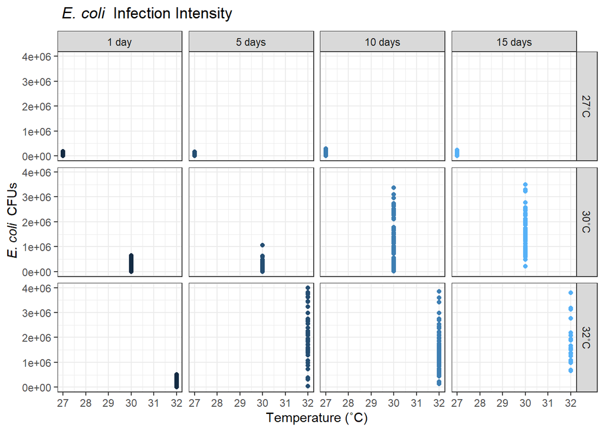

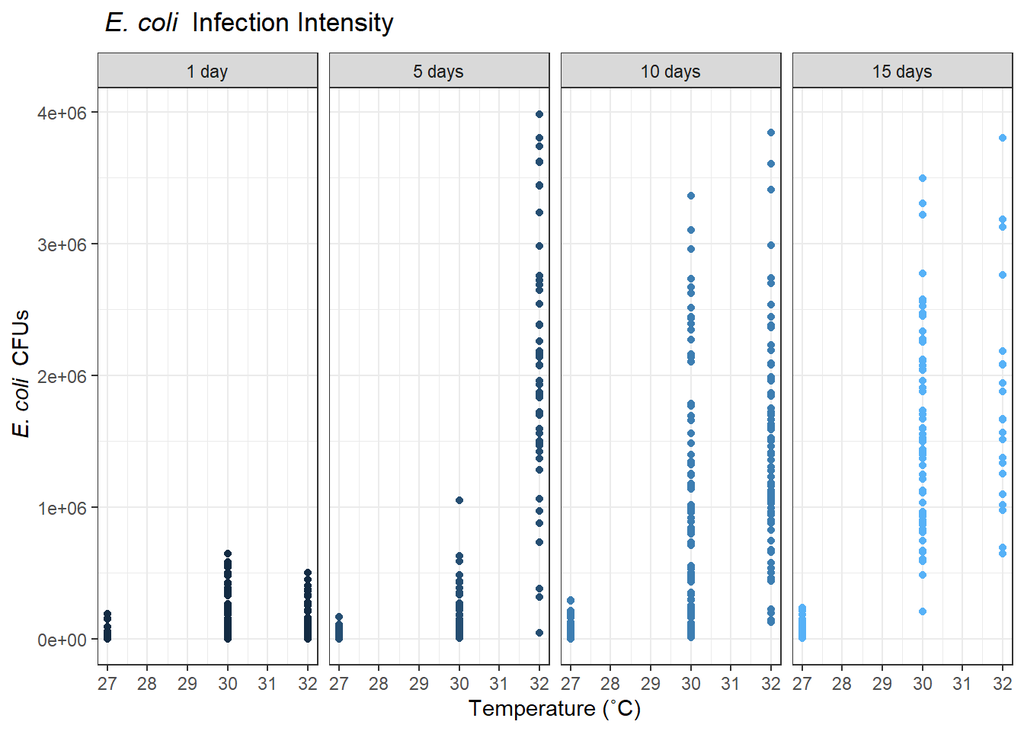

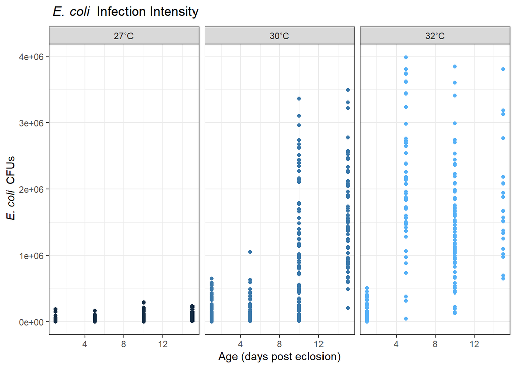

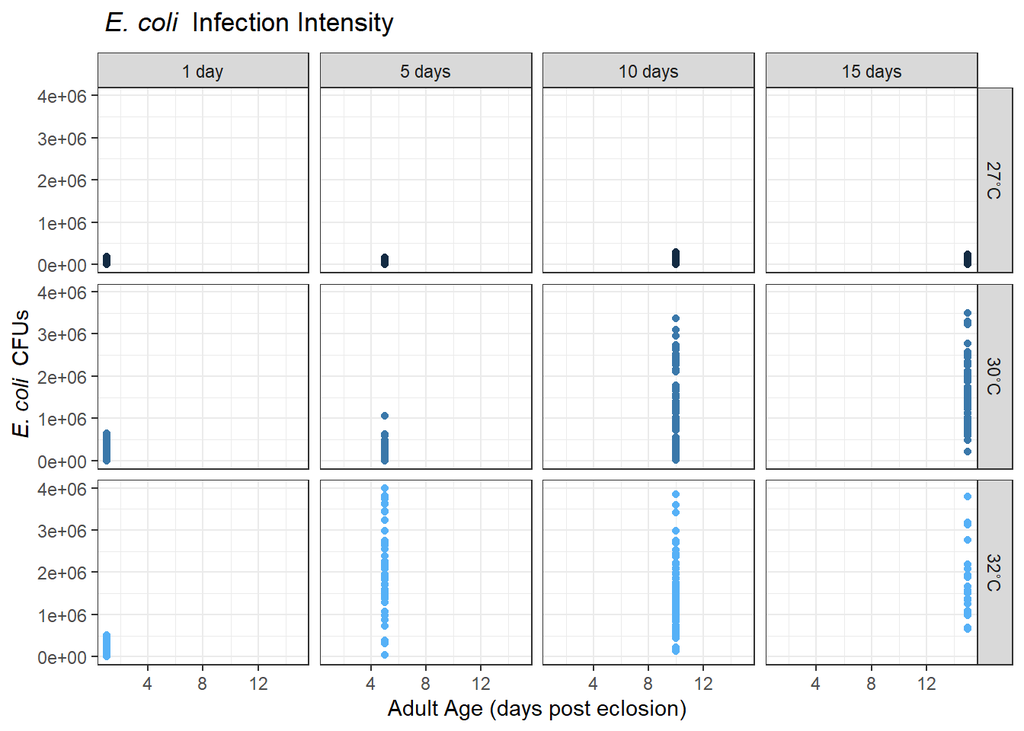

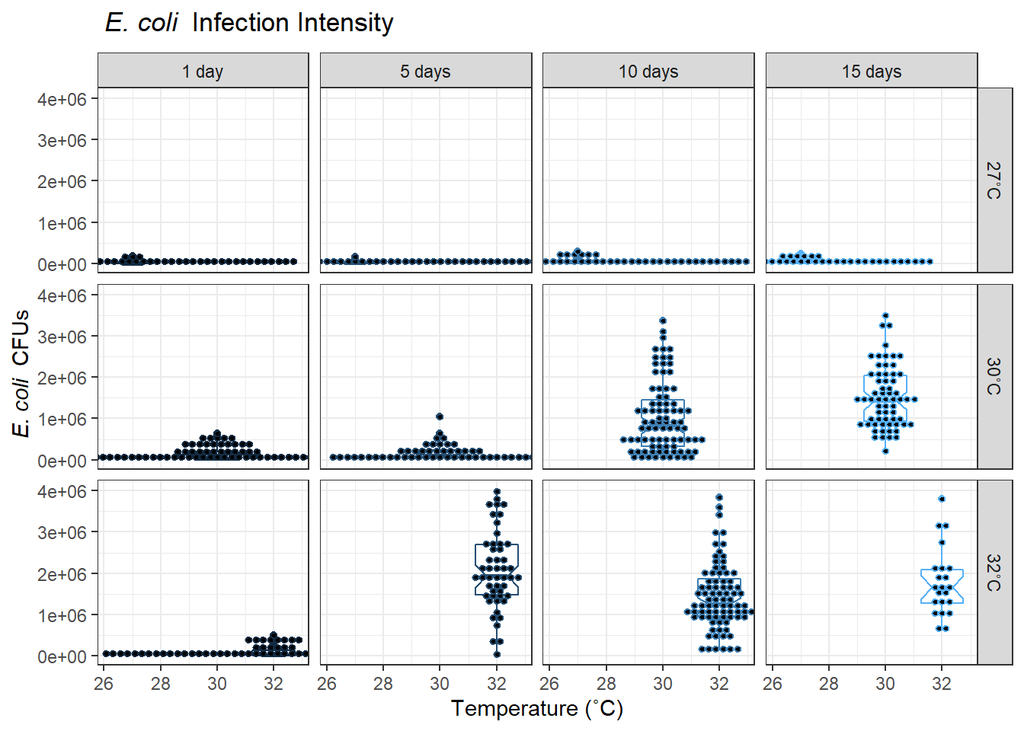

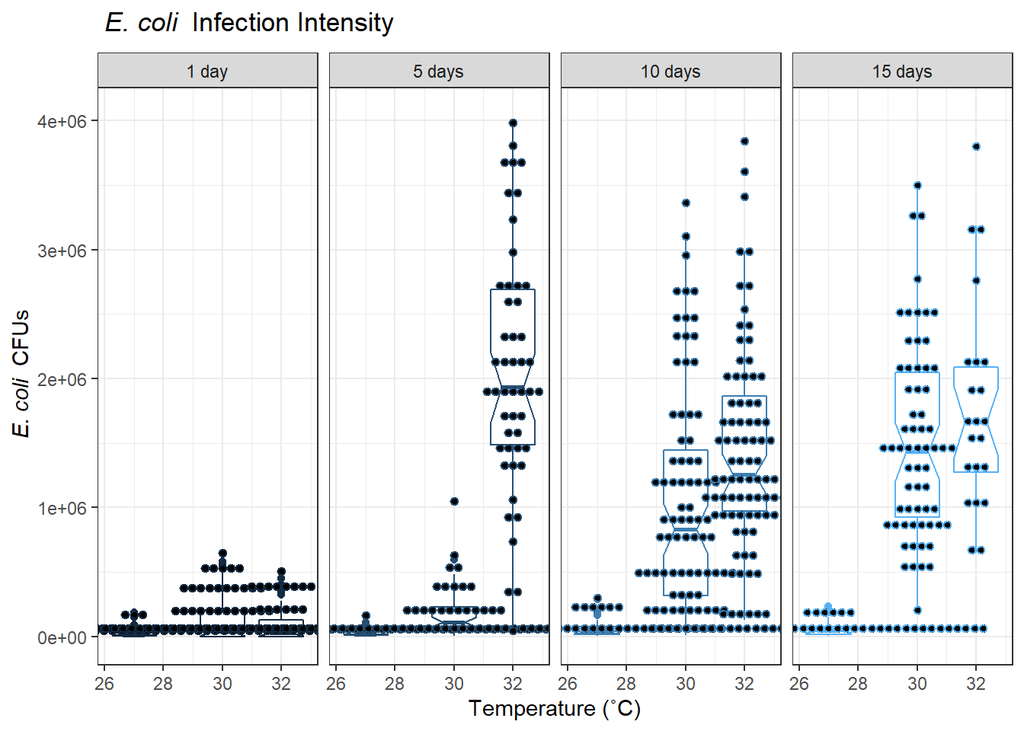

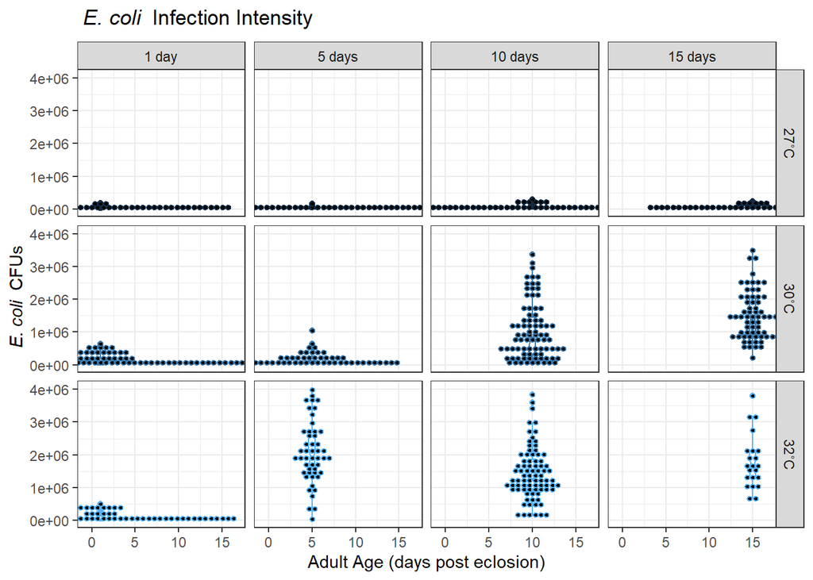

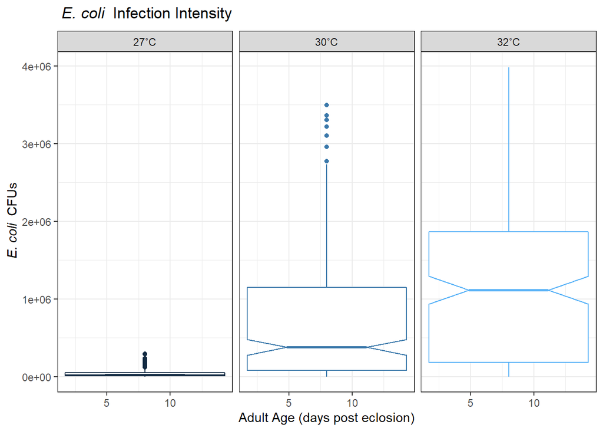

## Data Summary Figures

Then, we can calculate the mean, median, SE, SD for further exploration.

```r
#calculate the mean, median, SE, sd, etc.:
II_Summary <- II_Data %>%
  group_by(Temperature,Age) %>%
  summarise(mean_CFUs = mean(CFUs),
            median_CFUs = median(CFUs),
            sd_CFUs = sd(CFUs),
            n_CFUs = n(),
            SE_CFUs = sd(CFUs)/sqrt(n()))
II_Summary
```

```
## # A tibble: 12 × 7
## # Groups:   Temperature [3]
##    Temperature   Age mean_CFUs median_CFUs sd_CFUs n_CFUs SE_CFUs
##          <dbl> <dbl>     <dbl>       <dbl>   <dbl>  <int>   <dbl>
##  1          27     1    24184.        9000  40608.     49   5801.
##  2          27     5    28317.       17250  31429.     52   4358.
##  3          27    10    58540.       32000  70364.     55   9488.
##  4          27    15    60395.       43000  57644.     43   8791.
##  5          30     1   132343.       42000 174500.     83  19154.
##  6          30     5   177981.      112500 194841.     52  27020.
##  7          30    10  1032000       832000 863025.     83  94729.
##  8          30    15  1521143.     1432000 741178.     63  93380.
##  9          32     1   101000        28500 141758.     63  17860.
## 10          32     5  2066082.     1932000 940495.     49 134356.
## 11          32    10  1430341.     1254000 792195.     82  87483.
## 12          32    15  1796727.     1664000 820936.     22 175024.
```

We can graph the arithmetic means with standard errors:

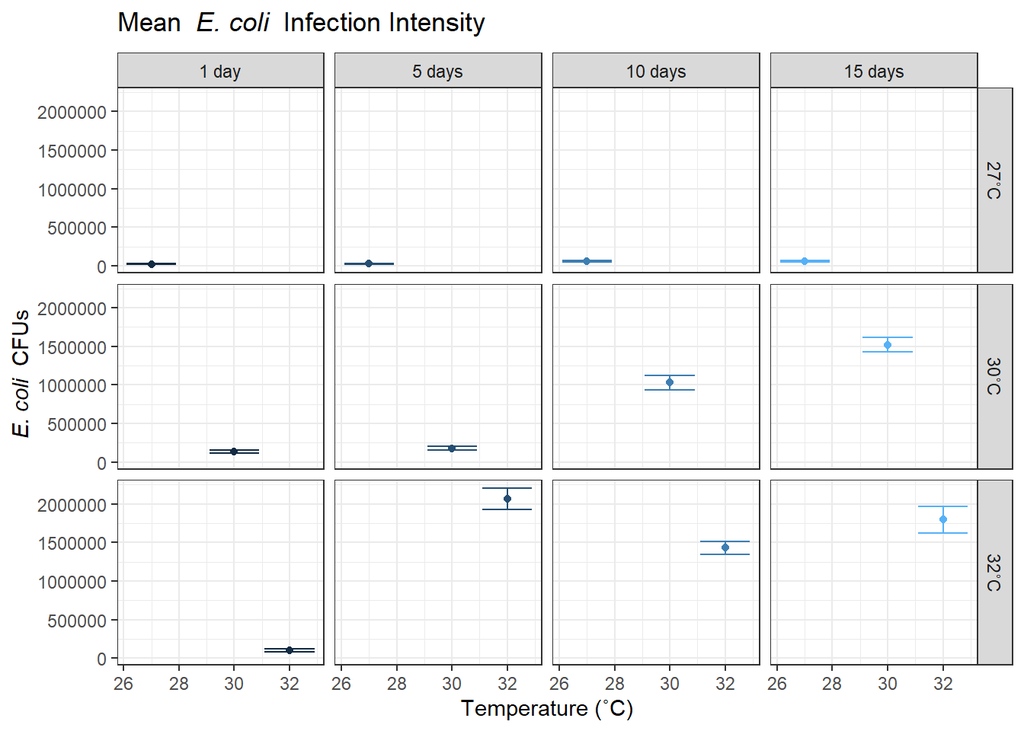

```
## # A tibble: 6 × 7
## # Groups:   Temperature [2]
##   Temperature   Age mean_CFUs median_CFUs sd_CFUs n_CFUs SE_CFUs
##         <dbl> <dbl>     <dbl>       <dbl>   <dbl>  <int>   <dbl>
## 1          27     1    24184.        9000  40608.     49   5801.
## 2          27     5    28317.       17250  31429.     52   4358.
## 3          27    10    58540.       32000  70364.     55   9488.
## 4          27    15    60395.       43000  57644.     43   8791.
## 5          30     1   132343.       42000 174500.     83  19154.
## 6          30     5   177981.      112500 194841.     52  27020.
```

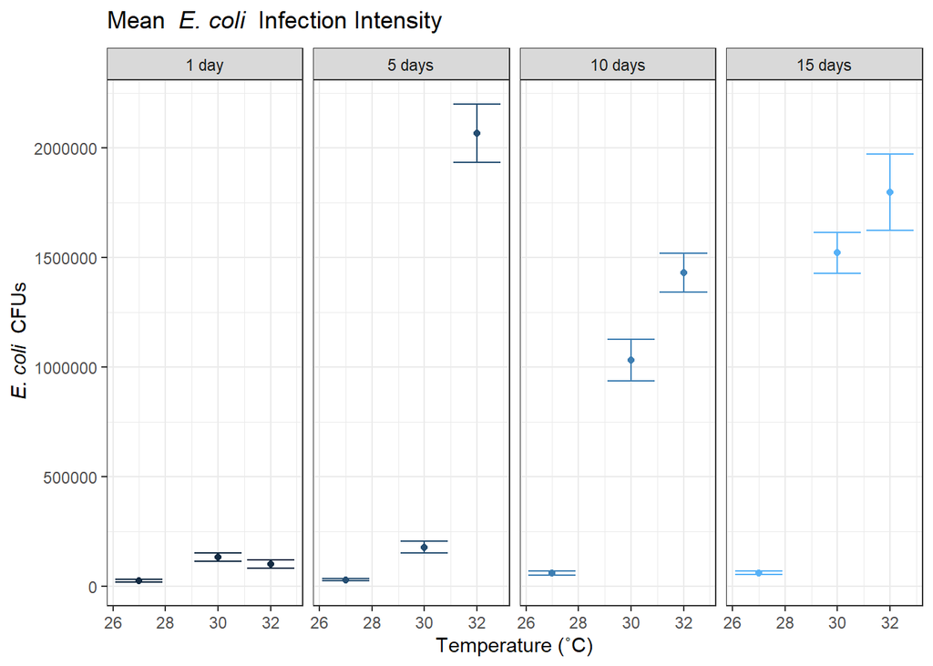

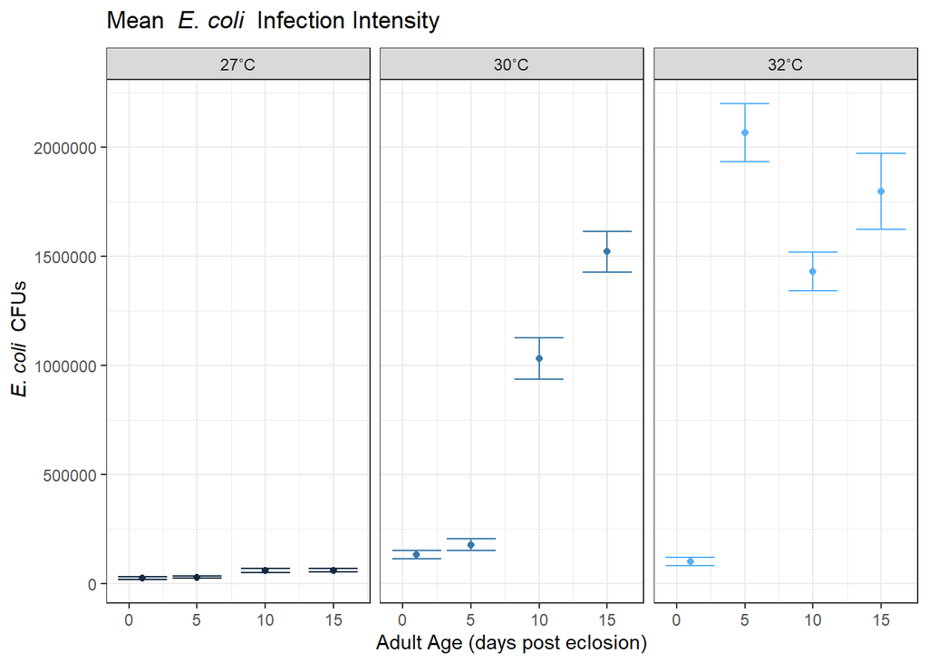

## Preliminary Data Analysis and Model Fitting

What is the distribution of the data? Are there any correlations? What can we determine from assessing the variance, etc.?

Common models for count data include the negative binomial regression, zero-inflated regression, and Poisson regression.

Helpful resources:

Delignette-Muller, M. L., & Dutang, C. (2015). fitdistrplus: An R Package for Fitting Distributions. Journal of Statistical Software, 64(4), 1–34. Alexander, N., 2012. Review: analysis of parasite and other skewed counts. Tropical Medicine & International Health 17, 684–693.. doi:10.1111/j.1365-3156.2012.02987.x https://doi.org/10.18637/jss.v064.i04 https://data.princeton.edu/wws509/r/overdispersion https://fukamilab.github.io/BIO202/04-C-zero-data.html https://stats.oarc.ucla.edu/r/dae/negative-binomial-regression/ https://www.jstatsoft.org/article/view/v027i08

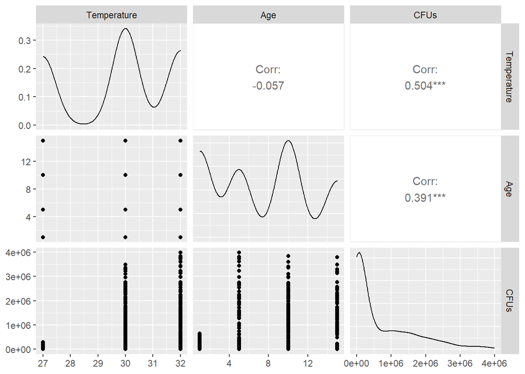

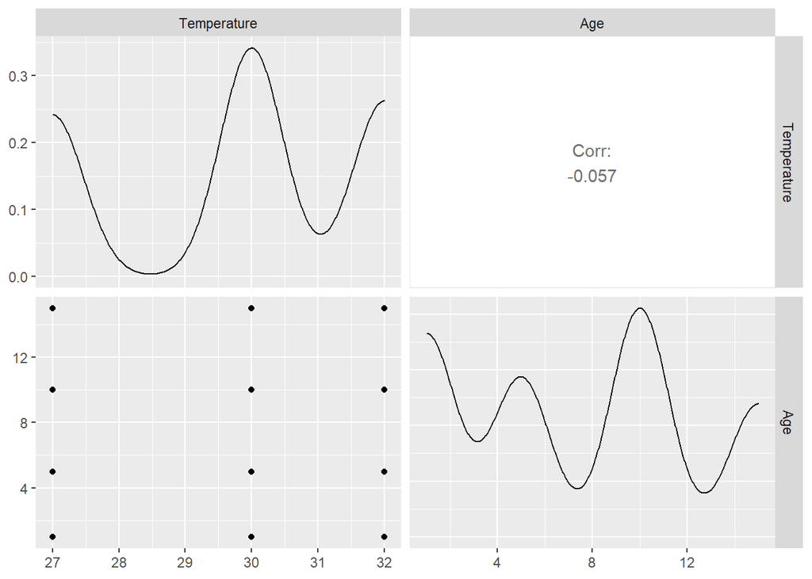

Plot histograms of the data and subsetted data.

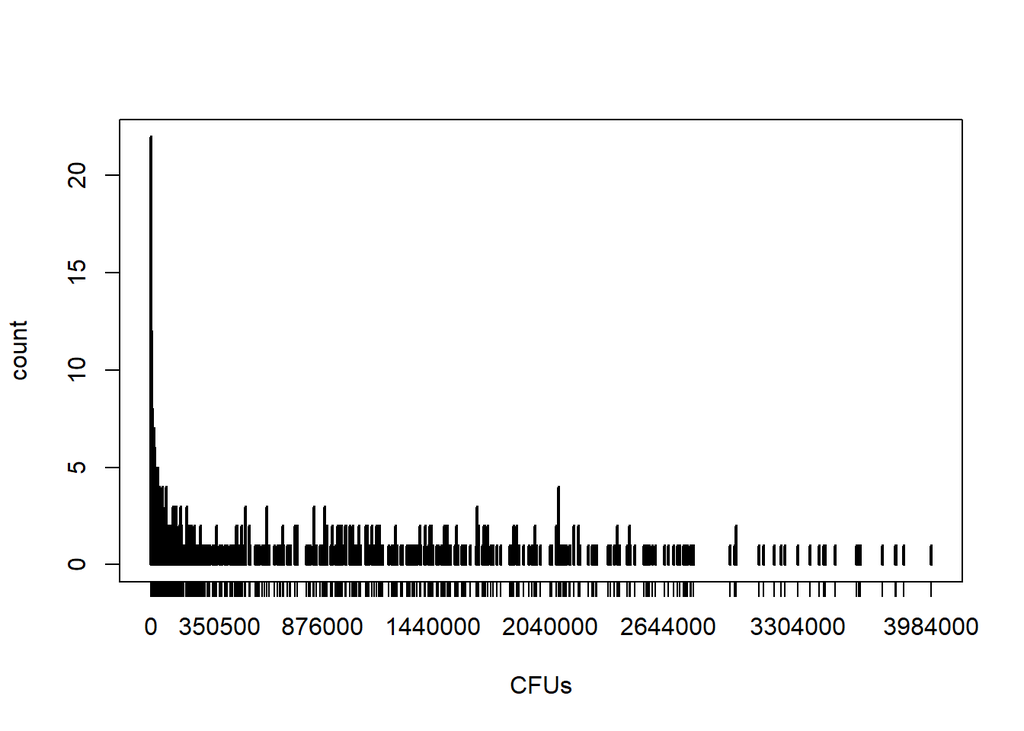

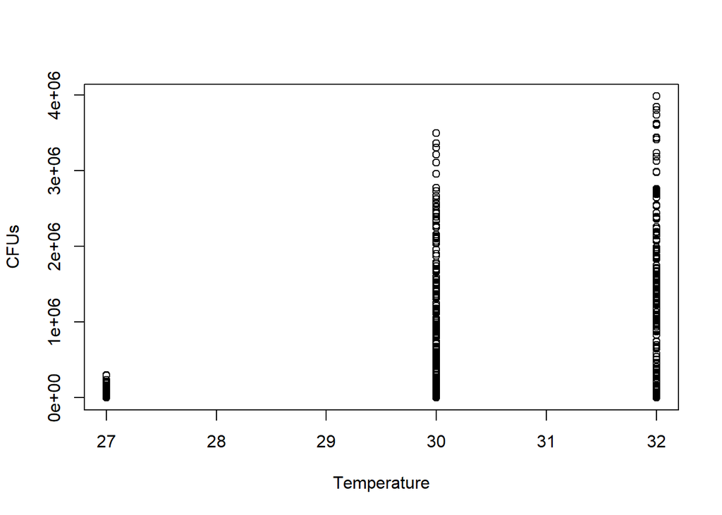

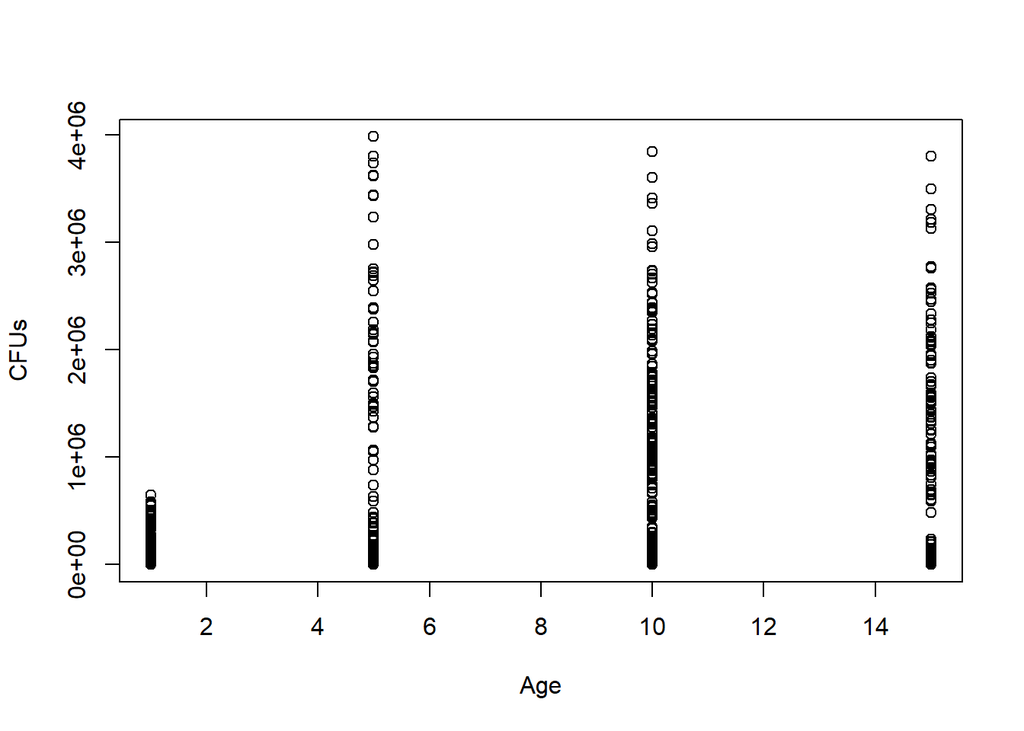

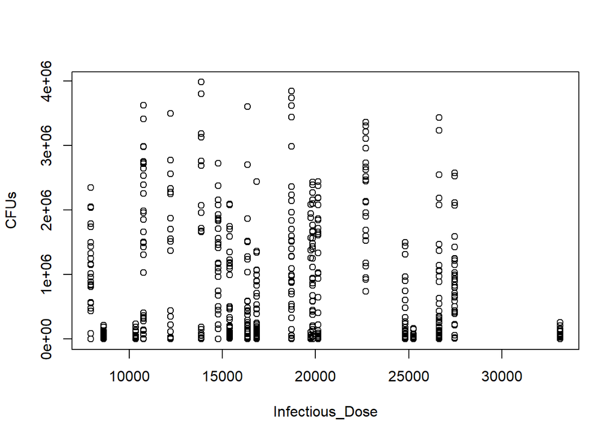

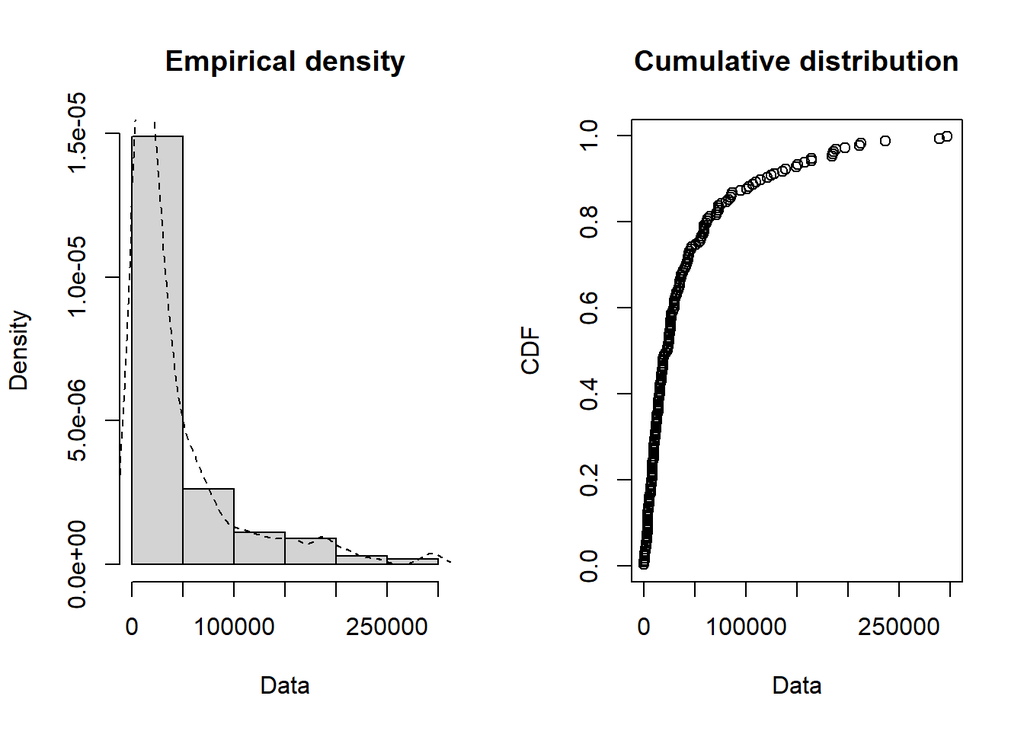

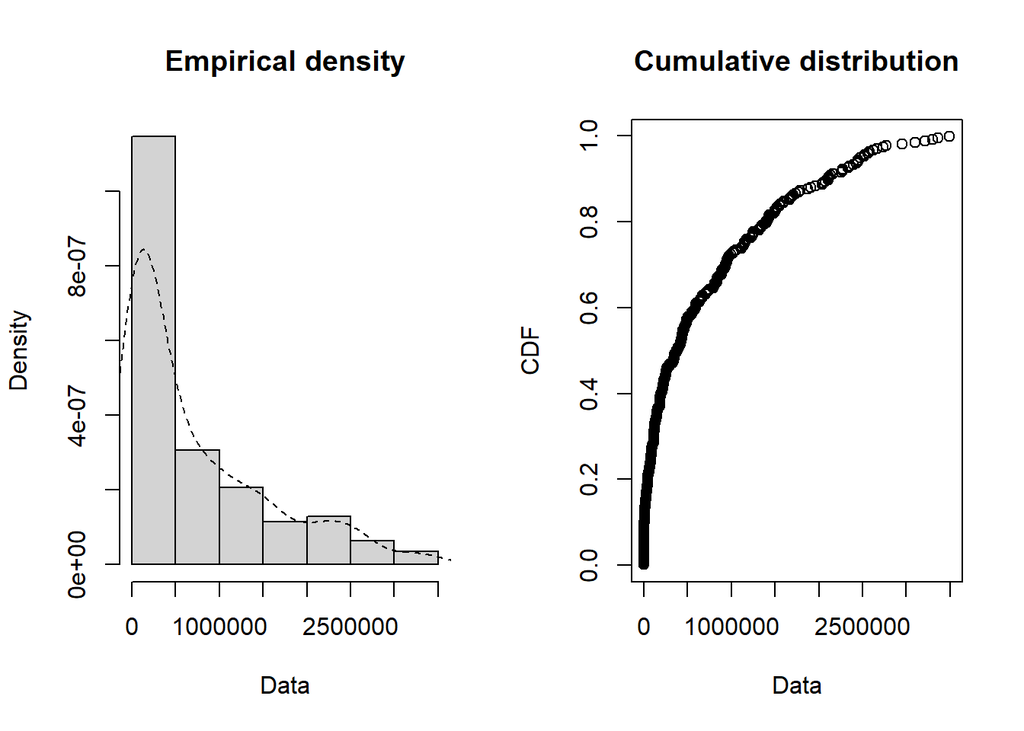

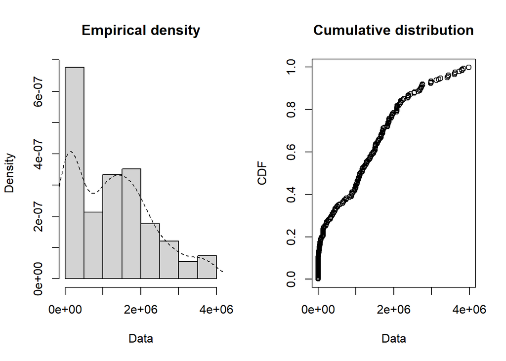

CFU data varies with Temp and Age, but not infectious dose. There also seem to be a large number of zero count values.

```r
#what percent of the data is made up of zeros?
100*sum(II_Data$CFUs ==0)/nrow(II_Data) #3.16%
```

```
## [1] 3.16092
```

3.16% of the data is made of zero-CFU counts.

What happens if we do a log(x+1) transformation to the CFU data?

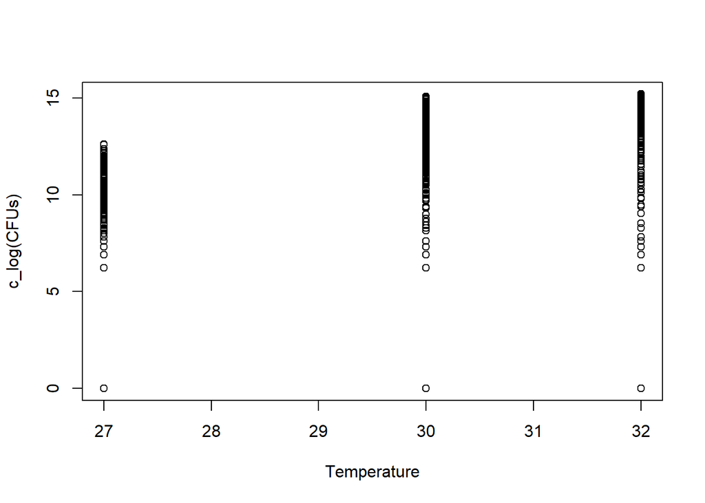

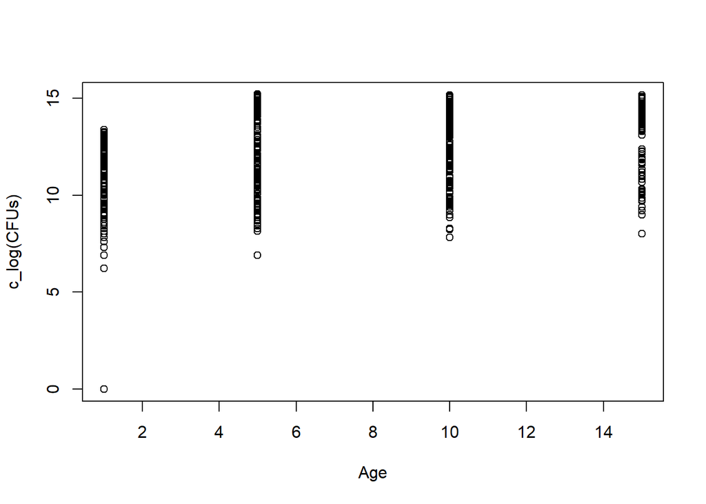

Now, plot the empirical distribution and densities for the CFU and log(x+1) transformed CFU data. Follow up with descriptive statistics of the data -

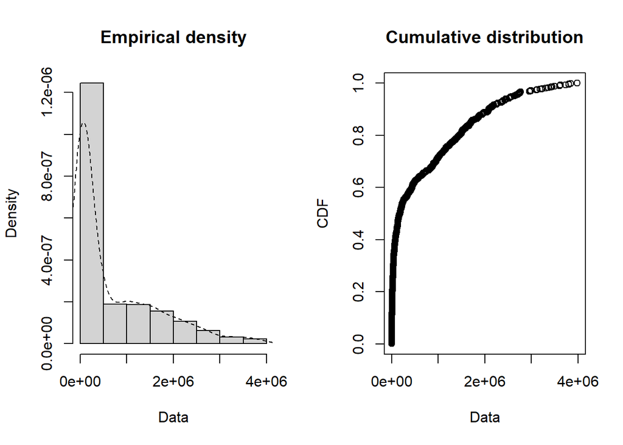

```r
#plot the empirical distribution and density (CDF)
plotdist(II_Data$CFUs, histo=TRUE,demp=TRUE)
```

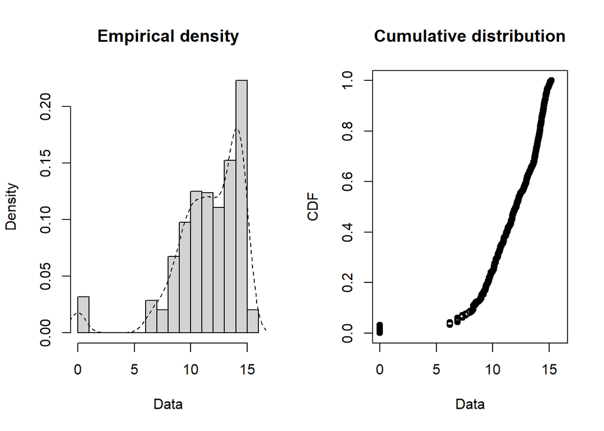

```r
plotdist(c_log(II_Data$CFUs),histo=TRUE,demp=TRUE)
```

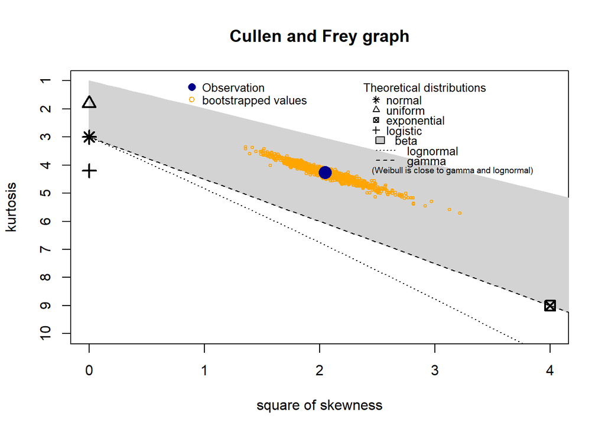

```
## summary statistics
## ------
## min:  0   max:  3984000
## median:  180500
## mean:  681923.5
## estimated sd:  906744.2
## estimated skewness:  1.431304
## estimated kurtosis:  4.26786
```

```r
#descriptive statistics of the data and graph
descdist(II_Data$CFUs, boot = 1000)
```

We are estimating skewness and kurtosis, using bootstrap samples. This is constructed by random sampling with replacement from original data set. There is high variance regardless of bootstrapping.

How does the variance compare to the mean of the CFU data?

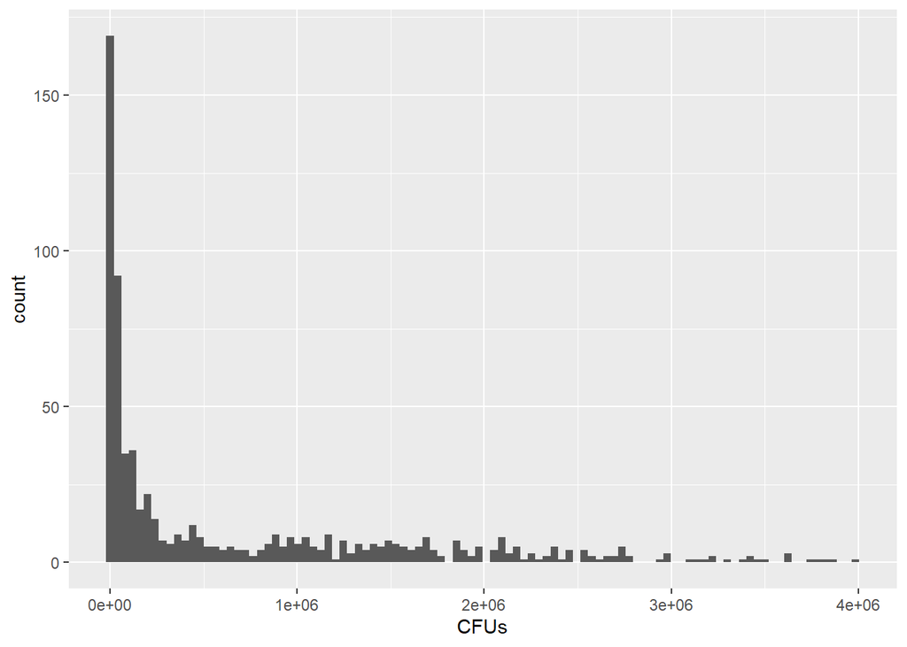

```
##         mean          var        ratio
## 6.819235e+05 8.221851e+11 1.205685e+06
```

Poisson assumption of equal mean and variance does not hold true. The variance is greater than the mean (ratio = 1.2e6) and is considered over-dispersed.

This suggests a Neg Binom model may be better (mean does not equal variance, which is assumed by Poisson dist).

First, we’ll look at the Poisson dist and Neg Bin dist.

```r
#assess fits:
#check to see if the data follow a poisson distribution
fit_poisson_CFUs <- fitdist((II_Data$CFUs),"pois")
summary(fit_poisson_CFUs)
```

```
## Fitting of the distribution ' pois ' by maximum likelihood
## Parameters :
##        estimate Std. Error
## lambda 681923.5         NA
## Loglikelihood:  -381063613   AIC:  762127229   BIC:  762127233
```

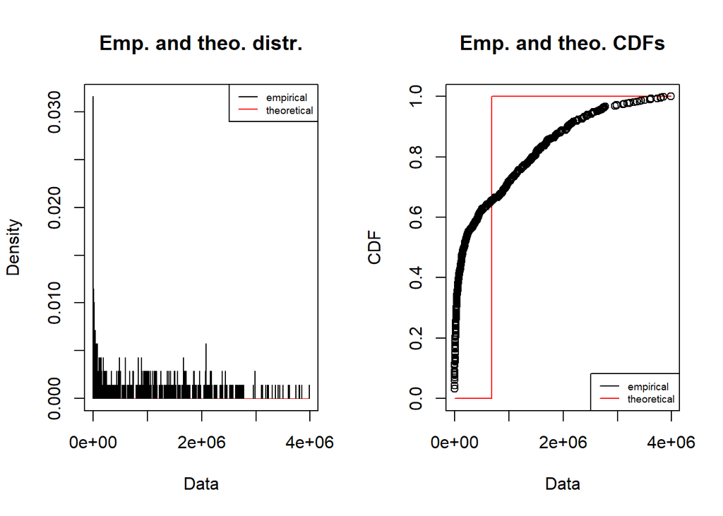

```r
plot(fit_poisson_CFUs)
```

```r
#check to see if the data follow a negative binomial distribution
fit_negbinom_CFUs <- fitdist((II_Data$CFUs), "nbinom")
summary(fit_negbinom_CFUs)
```

```
## Fitting of the distribution ' nbinom ' by maximum likelihood
## Parameters :
##          estimate Std. Error
## size 3.420331e-01         NA
## mu   6.822661e+05         NA
## Loglikelihood:  -9629.12   AIC:  19262.24   BIC:  19271.33
## Correlation matrix:
## [1] NA
```

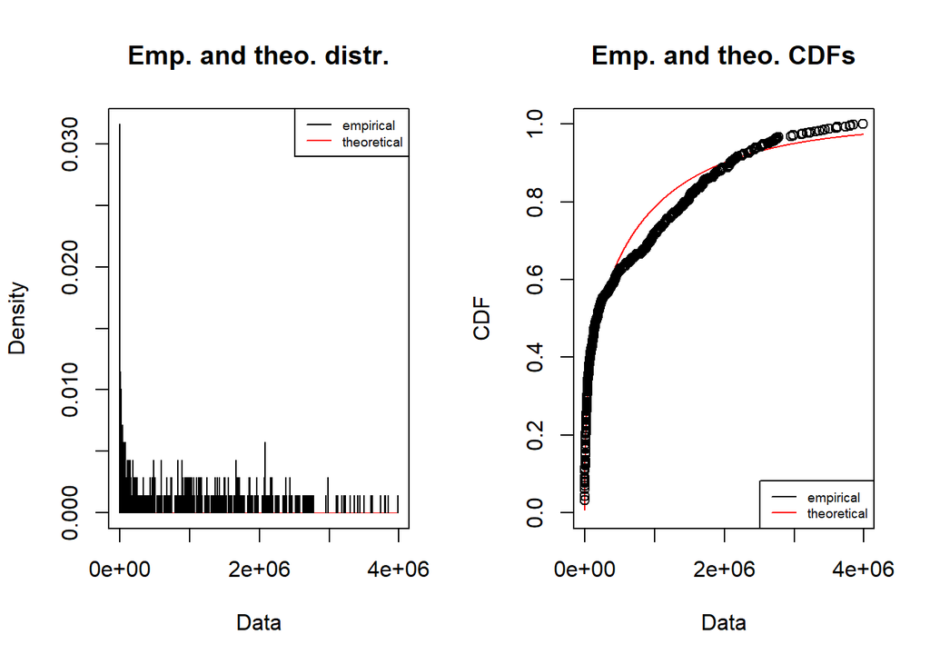

```r
plot(fit_negbinom_CFUs)
```

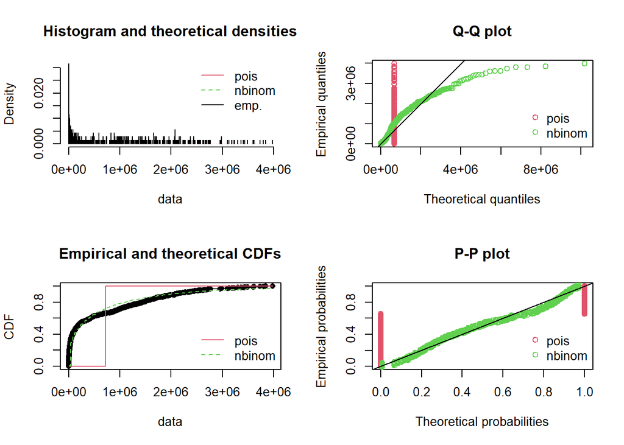

```r
#compare the two fits:

par(mfrow = c(2, 2))
#graphics.off()
plot.legend <- c("pois", "nbinom")
denscomp(list(fit_poisson_CFUs,fit_negbinom_CFUs),legendtext = plot.legend)
qqcomp(list(fit_poisson_CFUs,fit_negbinom_CFUs),legendtext = plot.legend)
cdfcomp(list(fit_poisson_CFUs,fit_negbinom_CFUs),legendtext = plot.legend)
ppcomp(list(fit_poisson_CFUs,fit_negbinom_CFUs),legendtext = plot.legend)
```

```r
#check goodness of fit statistics - chi square for discrete data
gofstat(list(fit_negbinom_CFUs, fit_poisson_CFUs),
        fitnames = c("nbinom", "pois"))
```

```
## Chi-squared statistic:  109.6618 Inf
## Degree of freedom of the Chi-squared distribution:  20 21
## Chi-squared p-value:  2.263674e-14 0
##    the p-value may be wrong with some theoretical counts < 5
## Chi-squared table:
##            obscounts theo nbinom theo pois
## <= 500            30    45.79180         0
## <= 3000           30    38.66537         0
## <= 6500           29    25.51343         0
## <= 11000          29    21.60291         0
## <= 16000          33    17.89404         0
## <= 25000          32    24.44854         0
## <= 35000          30    20.96379         0
## <= 47000          29    20.34635         0
## <= 71000          29    31.86313         0
## <= 106000         29    35.05328         0
## <= 135000         29    23.21798         0
## <= 188000         29    34.37366         0
## <= 272000         29    41.78116         0
## <= 430000         29    56.26156         0
## <= 592000         31    41.36140         0
## <= 888000         31    53.08861       696
## <= 1052000        29    21.73324         0
## <= 1276000        29    23.91389         0
## <= 1504000        30    19.32710         0
## <= 1720000        30    14.84938         0
## <= 2080000        30    19.27904         0
## <= 2472000        29    15.43783         0
## > 2472000         41    49.23252         0
##
## Goodness-of-fit criteria
##                                  nbinom      pois
## Akaike's Information Criterion 19262.24 762127229
## Bayesian Information Criterion 19271.33 762127233
```

```r
#negative binomial model is a much better fit than poisson

#for the log CFUs dist:
fit_norm_logCFUs <- fitdist((II_Data$logCFUs),"norm")
summary(fit_norm_logCFUs)
```

```
## Fitting of the distribution ' norm ' by maximum likelihood
## Parameters :
##       estimate Std. Error
## mean 11.555800 0.11575962
## sd    3.053948 0.08185437
## Loglikelihood:  -1764.62   AIC:  3533.24   BIC:  3542.331
## Correlation matrix:
##               mean            sd
## mean  1.000000e+00 -2.693079e-10
## sd   -2.693079e-10  1.000000e+00
```

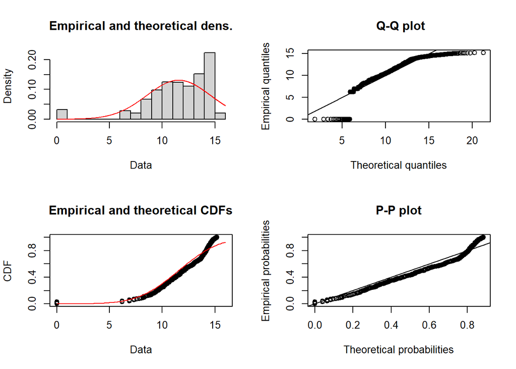

```r
plot(fit_norm_logCFUs)
```

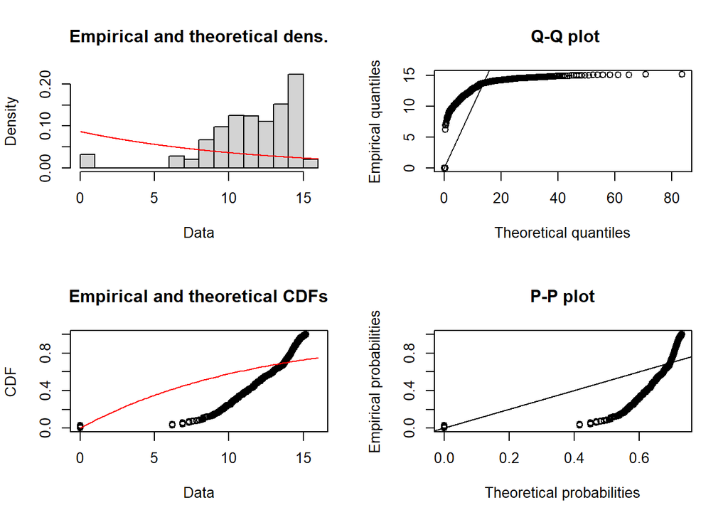

```r
#fit_poisson_logCFUs <- fitdist((II_Data$logCFUs),"pois")

fit_exp_logCFUs <- fitdist((II_Data$logCFUs),"exp")
plot(fit_exp_logCFUs) #not good
```

```r
##############
##model fitting:
#fit Poisson, quasiPoisson, and negative binomial distributions with log link (modeling the mean not the actual data using log link)
glmPoisson <- glm(CFUs ~ Temperature*Age, data=II_Data, family = poisson(link = "log"))
glmQuasiPoisson <- glm(CFUs ~ Temperature*Age, data=II_Data, family = quasipoisson(link = "log"))
glmNegBinomial <- glm.nb(CFUs ~ Temperature*Age, data=II_Data,link="log")
glmNegBinomial_additive <- glm.nb(CFUs ~ Temperature+Age, data=II_Data,link="log") #leaves out interaction term
```

```r
#check models:
summary(glmPoisson)
```

```
##
## Call:
## glm(formula = CFUs ~ Temperature * Age, family = poisson(link = "log"),
##     data = II_Data)
##
## Deviance Residuals:
##     Min       1Q   Median       3Q      Max
## -1605.5   -571.9   -232.1    173.0   2449.6
##
## Coefficients:
##                   Estimate Std. Error z value Pr(>|z|)
## (Intercept)     -8.669e+00  2.924e-03   -2965   <2e-16 ***
## Temperature      6.850e-01  9.335e-05    7338   <2e-16 ***
## Age              6.653e-01  2.449e-04    2716   <2e-16 ***
## Temperature:Age -1.739e-02  7.866e-06   -2211   <2e-16 ***
## ---
## Signif. codes:  0 '***' 0.001 '**' 0.01 '*' 0.05 '.' 0.1 ' ' 1
##
## (Dispersion parameter for poisson family taken to be 1)
##
##     Null deviance: 762117945  on 695  degrees of freedom
## Residual deviance: 342540627  on 692  degrees of freedom
## AIC: 342549916
##
## Number of Fisher Scoring iterations: 6
```

```r
#Residual deviance: 342540627  on 692  degrees of freedom
#AIC: 342549916

summary(glmQuasiPoisson)
```

```
##
## Call:
## glm(formula = CFUs ~ Temperature * Age, family = quasipoisson(link = "log"),
##     data = II_Data)
##
## Deviance Residuals:
##     Min       1Q   Median       3Q      Max
## -1605.5   -571.9   -232.1    173.0   2449.6
##
## Coefficients:
##                  Estimate Std. Error t value Pr(>|t|)
## (Intercept)     -8.669337   2.169038  -3.997 7.11e-05 ***
## Temperature      0.685033   0.069243   9.893  < 2e-16 ***
## Age              0.665303   0.181666   3.662 0.000269 ***
## Temperature:Age -0.017391   0.005835  -2.981 0.002978 **
## ---
## Signif. codes:  0 '***' 0.001 '**' 0.01 '*' 0.05 '.' 0.1 ' ' 1
##
## (Dispersion parameter for quasipoisson family taken to be 550206.2)
##
##     Null deviance: 762117945  on 695  degrees of freedom
## Residual deviance: 342540627  on 692  degrees of freedom
## AIC: NA
##
## Number of Fisher Scoring iterations: 6
```

```r
#Residual deviance: 342540627  on 692  degrees of freedom
#AIC: NA

summary(glmNegBinomial)
```

```
##
## Call:
## glm.nb(formula = CFUs ~ Temperature * Age, data = II_Data, link = "log",
##     init.theta = 0.5548731255)
##
## Deviance Residuals:
##     Min       1Q   Median       3Q      Max
## -3.8496  -0.9400  -0.3797   0.2275   2.2592
##
## Coefficients:
##                  Estimate Std. Error z value Pr(>|z|)
## (Intercept)     -3.559337   1.394446  -2.553   0.0107 *
## Temperature      0.502902   0.046715  10.765  < 2e-16 ***
## Age             -0.653006   0.159179  -4.102 4.09e-05 ***
## Temperature:Age  0.027626   0.005358   5.156 2.52e-07 ***
## ---
## Signif. codes:  0 '***' 0.001 '**' 0.01 '*' 0.05 '.' 0.1 ' ' 1
##
## (Dispersion parameter for Negative Binomial(0.5549) family taken to be 1)
##
##     Null deviance: 1488.50  on 695  degrees of freedom
## Residual deviance:  867.08  on 692  degrees of freedom
## AIC: 18787
##
## Number of Fisher Scoring iterations: 1
##
##
##               Theta:  0.5549
##           Std. Err.:  0.0255
##
##  2 x log-likelihood:  -18776.9520
```

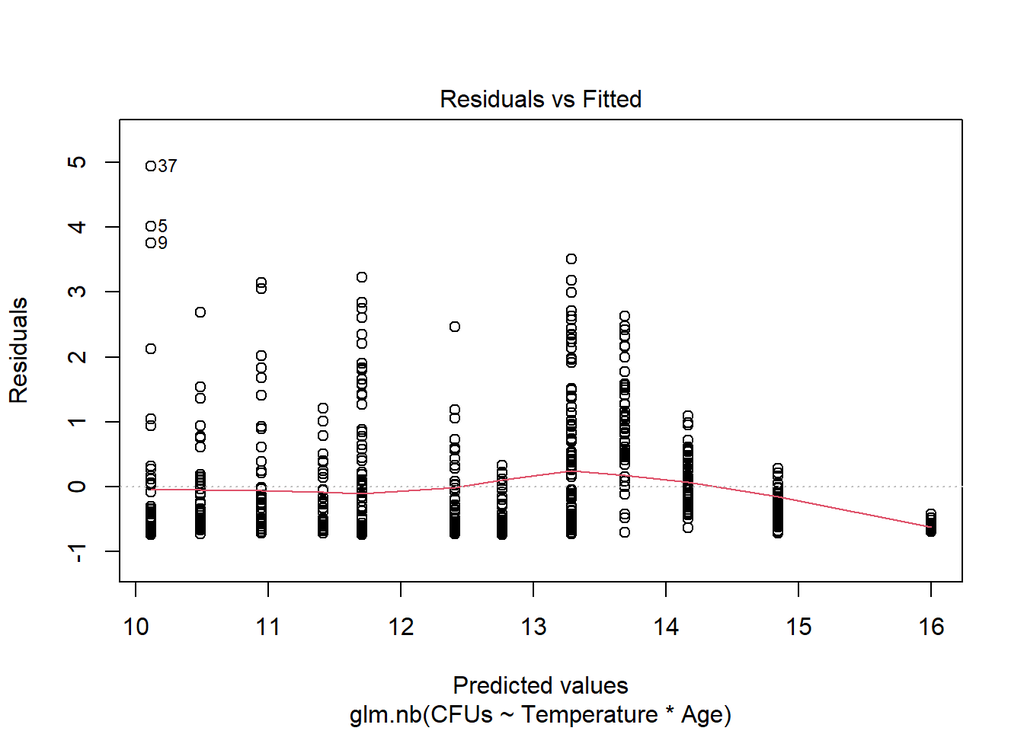

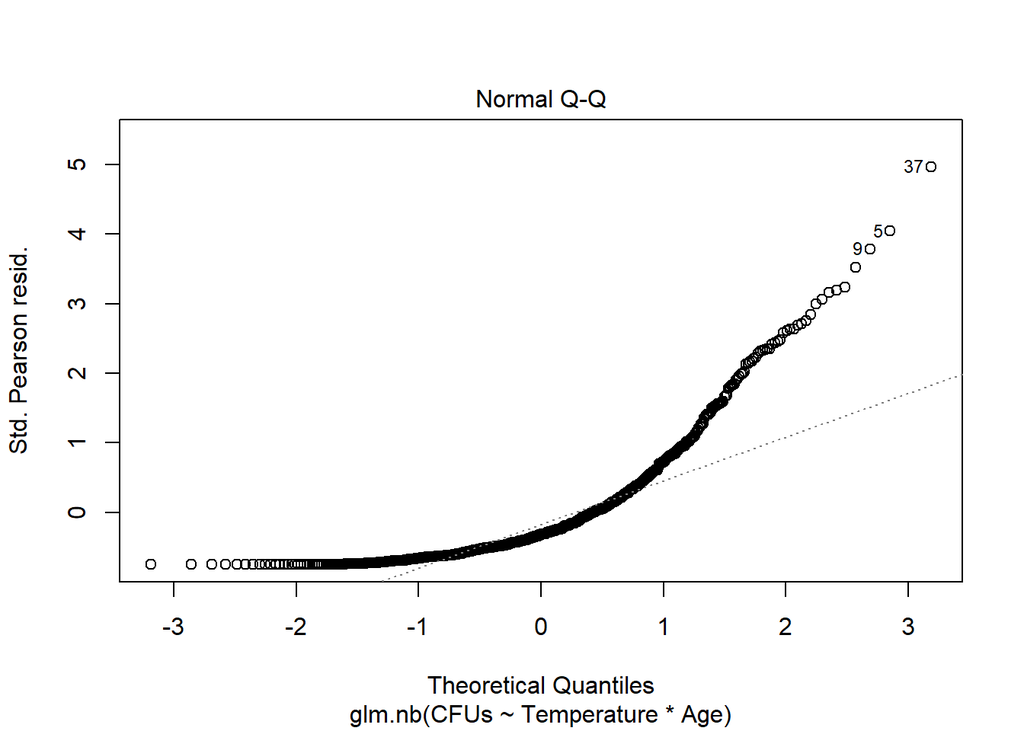

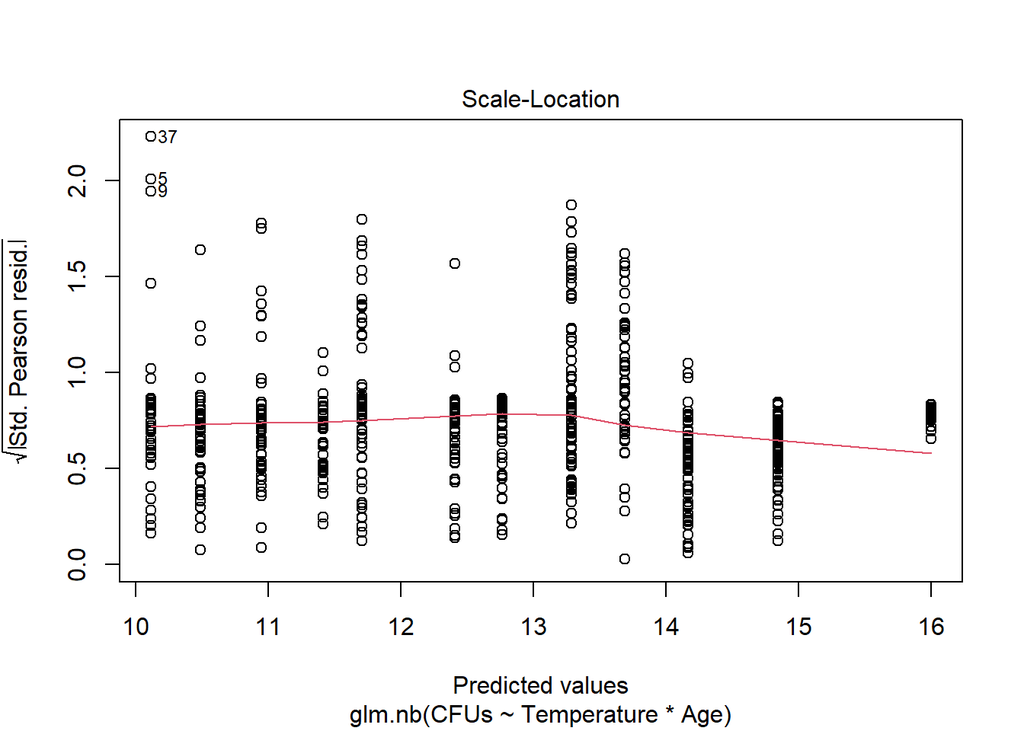

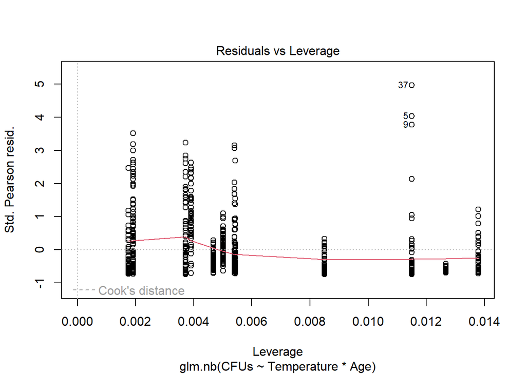

```r
plot(glmNegBinomial)
```

```r
#Residual deviance:  867.08  on 692  degrees of freedom
#AIC: 18787
# 2 x log-likelihood:  -18776.9520
#Theta:  0.5549
#Std. Err.:  0.0255


summary(glmNegBinomial_additive)
```

```
##
## Call:
## glm.nb(formula = CFUs ~ Temperature + Age, data = II_Data, link = "log",
##     init.theta = 0.5454901466)
##
## Deviance Residuals:
##     Min       1Q   Median       3Q      Max
## -3.8757  -0.9157  -0.3703   0.2401   2.8469
##
## Coefficients:
##             Estimate Std. Error z value Pr(>|z|)
## (Intercept) -8.74784    0.79860  -10.95   <2e-16 ***
## Temperature  0.67969    0.02652   25.63   <2e-16 ***
## Age          0.15995    0.01018   15.71   <2e-16 ***
## ---
## Signif. codes:  0 '***' 0.001 '**' 0.01 '*' 0.05 '.' 0.1 ' ' 1
##
## (Dispersion parameter for Negative Binomial(0.5455) family taken to be 1)
##
##     Null deviance: 1463.74  on 695  degrees of freedom
## Residual deviance:  868.84  on 693  degrees of freedom
## AIC: 18801
##
## Number of Fisher Scoring iterations: 1
##
##
##               Theta:  0.5455
##           Std. Err.:  0.0250
##
##  2 x log-likelihood:  -18793.1080
```

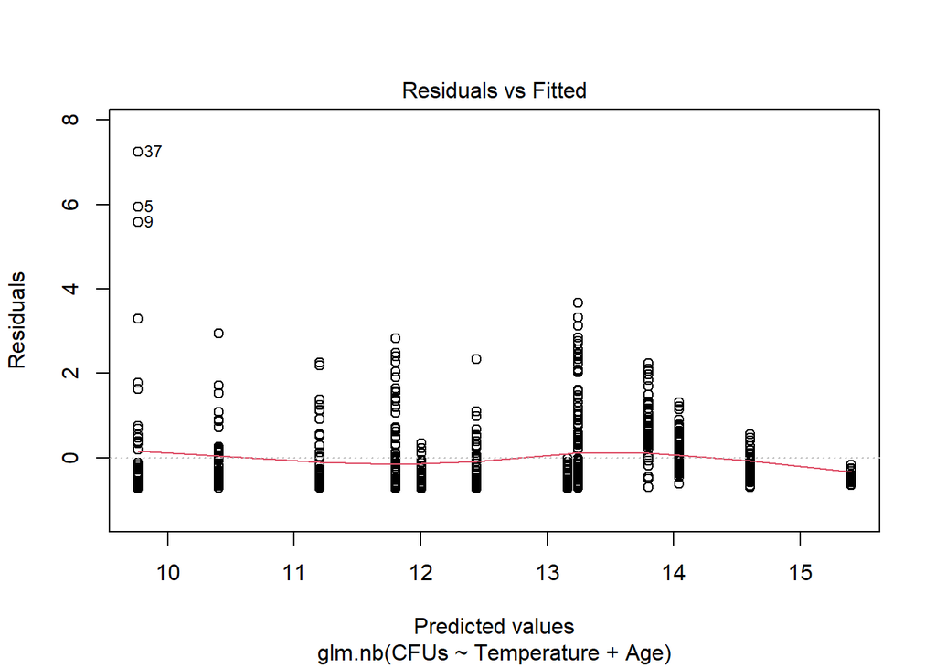

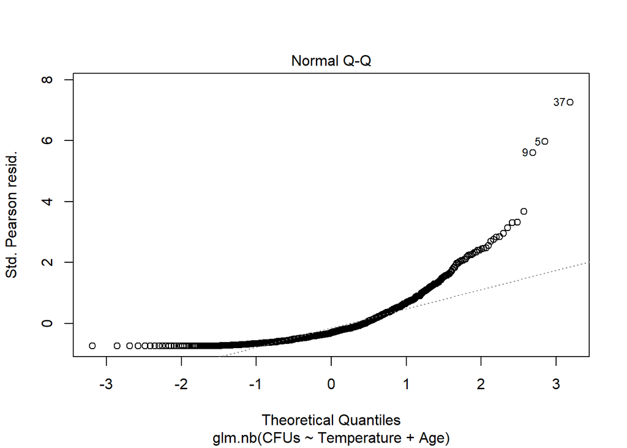

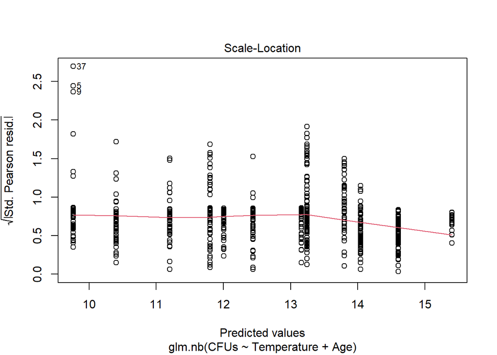

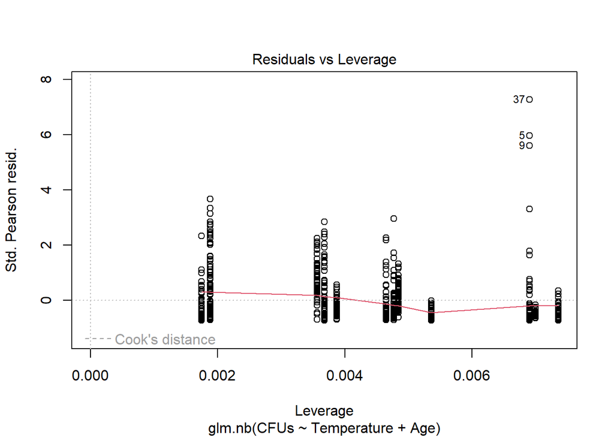

```r
plot(glmNegBinomial_additive)
```

```r
#Residual deviance:  868.84  on 693  degrees of freedom
#AIC: 18801
#Theta:  0.5455
#Std. Err.:  0.0250
# 2 x log-likelihood:  -18793.1080
```

So far, it looks like the negative binomial distribution is the better fit.

Does this match the assumption of overdispersion in the Poisson model? How does the negative binomial model compare to the poisson model?

```r
###
#checking for overdispersion in Poisson model:
E2 <- resid(glmPoisson, type = "pearson")
N  <- nrow(II_Data)
p  <- length(coef(glmPoisson))
sum(E2^2) / (N - p) # =  550206.2 #overdispersion present!
```

```
## [1] 550206.2
```

```r
#show it another way:
#how much larger/smaller is the variance relative to the mean for the poisson?
pr <- residuals(glmPoisson,"pearson")
phi <- sum(pr^2)/df.residual(glmPoisson)
round(c(phi,sqrt(phi)),4) #variance is 550206x the mean
```

```
## [1] 550206.1879    741.7588
```

```r
qchisq(0.95, df.residual(glmNegBinomial)) #this gives the threshold value
```

```
## [1] 754.3079
```

```r
#threshold value for this model is 754.3079
deviance(glmNegBinomial) #deviance = 867
```

```
## [1] 867.0777
```

```r
pr <- residuals(glmNegBinomial,"pearson")
sum(pr^2) #pearson chi square value - compare to the threshold, if greater, not signif
```

```
## [1] 527.523
```

```r
#chi square value is less than threshold at 527
#suggests model is a good fit

#for negative binomial model, need to use log likelihood to compare to poisson model
-2*(logLik(glmPoisson)-logLik(glmNegBinomial))
```

```
## 'log Lik.' 342531131 (df=4)
```

```r
#'log Lik.' 342531131 (df=4) when temp and age are continuous vars.
#'log Lik.' 193430370 (df=12) for categorical predictor vars.
lrtest(glmPoisson,glmNegBinomial)
```

```
## Likelihood ratio test
##
## Model 1: CFUs ~ Temperature * Age
## Model 2: CFUs ~ Temperature * Age
##   #Df     LogLik Df     Chisq Pr(>Chisq)
## 1   4 -171274954
## 2   5      -9388  1 342531131  < 2.2e-16 ***
## ---
## Signif. codes:  0 '***' 0.001 '**' 0.01 '*' 0.05 '.' 0.1 ' ' 1
```

```r
#chisq=342531131;  pr(>chisq) = < 2.2e-16 ***
#Neg binom is best fit compared to Poisson model

#also should compare diff neg binomial model options (should the interaction term be included in the model?)
glmNegBinomial <- glm.nb(CFUs ~ Temperature*Age, data=II_Data,link="log")
glmNegBinomial_additive <- glm.nb(CFUs ~ Temperature+Age, data=II_Data,link="log") #leaves out interaction term
anova(glmNegBinomial,glmNegBinomial_additive)
```

```
## Likelihood ratio tests of Negative Binomial Models
##
## Response: CFUs
##               Model     theta Resid. df    2 x log-lik.   Test    df LR stat.
## 1 Temperature + Age 0.5454901       693       -18793.11
## 2 Temperature * Age 0.5548731       692       -18776.95 1 vs 2     1  16.1559
##        Pr(Chi)
## 1
## 2 5.833665e-05
```

```r
#this indicates that the interaction term is a significant predictor of CFUs response
#(LR stat = 16.1559, pr(chi)=5.833665e-05)

#theta is the precision of the multiplicative random effect = 1/σ2 for the neg binom model
glmNegBinomial$theta #theta = 0.5548731
```

```
## [1] 0.5548731
```

```r
1/glmNegBinomial$theta #estimated variance = 1.802214
```

```
## [1] 1.802214
```

```r
###
# Dispersion statistic for neg binomial model:
#how much larger/smaller is the variance relative to the mean for the Neg Binomial model?
phi <- sum(pr^2)/df.residual(glmNegBinomial)
round(c(phi,sqrt(phi)),4) #variance is 0.7623 times smaller than the mean
```

```
## [1] 0.7623 0.8731
```

```r
#show another way too:
E2 <- resid(glmNegBinomial, type = "pearson")
N  <- nrow(II_Data)
p  <- length(coef(glmNegBinomial)) + 1  # '+1' is for variance in NB model
sum(E2^2) / (N - p) #= 0.763 ==== under-dispersion due to neg binomial model
```

```
## [1] 0.7634196
```

```r
#may have over-corrected for the zero inflation by using a negative binomial fit --
#check to see if other fits may be better

#################
#also check models with logCFUs to see if these may be simpler to use
glmPoisson <- glm(logCFUs ~ Temperature*Age, data=II_Data, family = poisson(link = "log"))
```

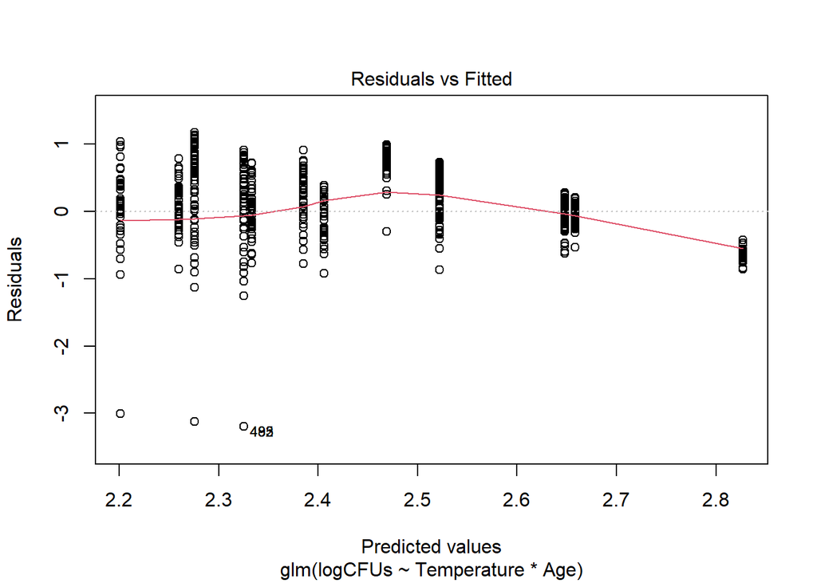

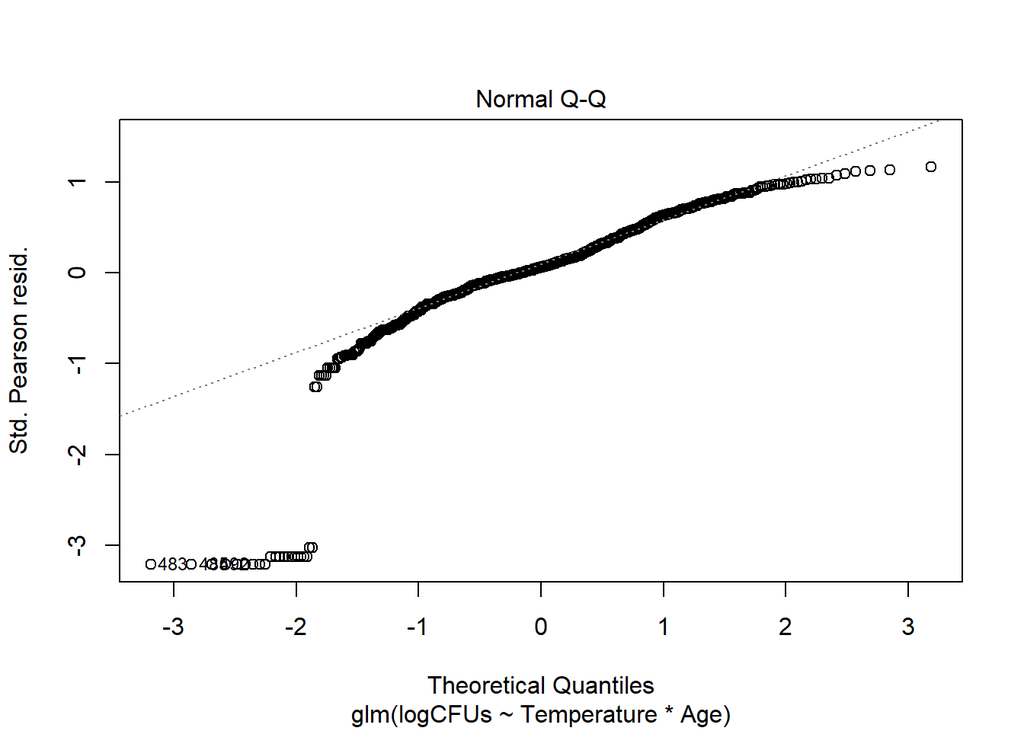

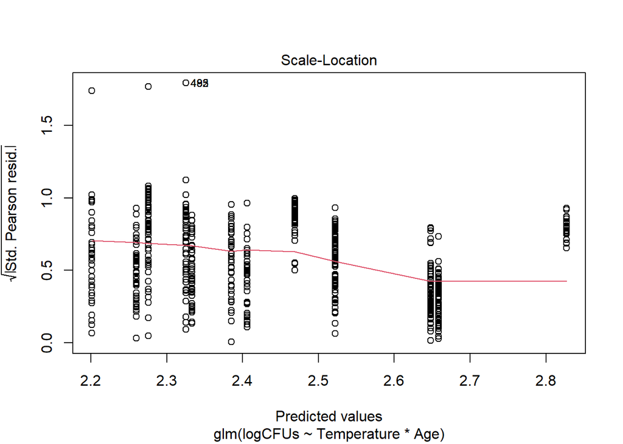

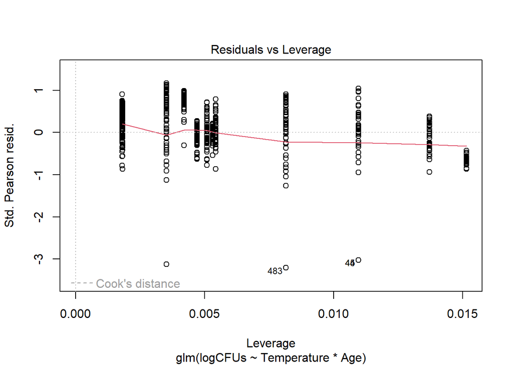

```r
plot(glmPoisson)
```

```r
glmQuasiPoisson <- glm(logCFUs ~ Temperature*Age, data=II_Data, family = quasipoisson(link = "log"))
summary(glmQuasiPoisson)
```

```
##
## Call:
## glm(formula = logCFUs ~ Temperature * Age, family = quasipoisson(link = "log"),
##     data = II_Data)
##
## Deviance Residuals:
##     Min       1Q   Median       3Q      Max
## -4.5231  -0.2298   0.0618   0.4192   1.1048
##
## Coefficients:
##                   Estimate Std. Error t value Pr(>|t|)
## (Intercept)      1.6295535  0.2434363   6.694 4.49e-11 ***
## Temperature      0.0206209  0.0081239   2.538 0.011358 *
## Age             -0.0998171  0.0264269  -3.777 0.000172 ***
## Temperature:Age  0.0042395  0.0008845   4.793 2.01e-06 ***
## ---
## Signif. codes:  0 '***' 0.001 '**' 0.01 '*' 0.05 '.' 0.1 ' ' 1
##
## (Dispersion parameter for quasipoisson family taken to be 0.5445632)
##
##     Null deviance: 820.37  on 695  degrees of freedom
## Residual deviance: 591.98  on 692  degrees of freedom
## AIC: NA
##
## Number of Fisher Scoring iterations: 4
```

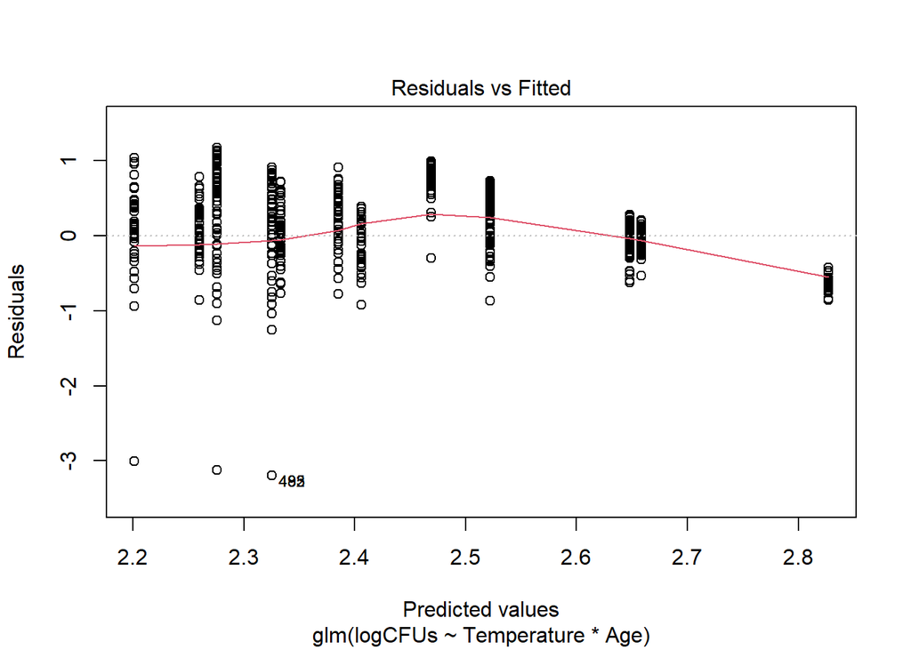

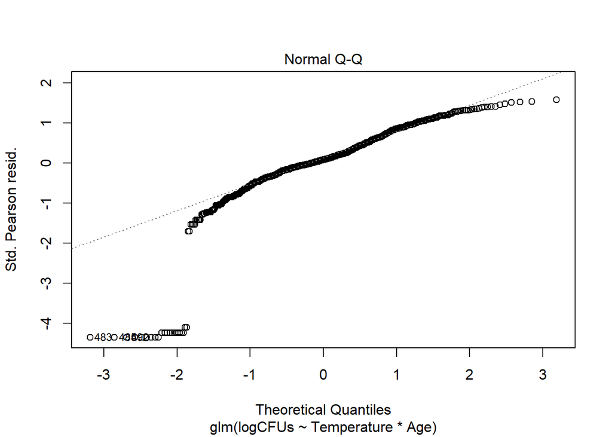

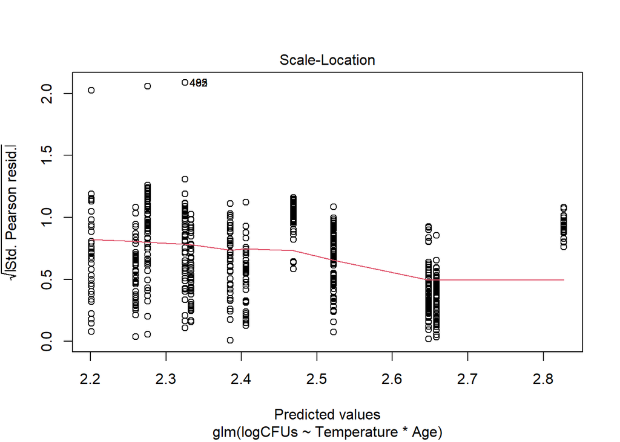

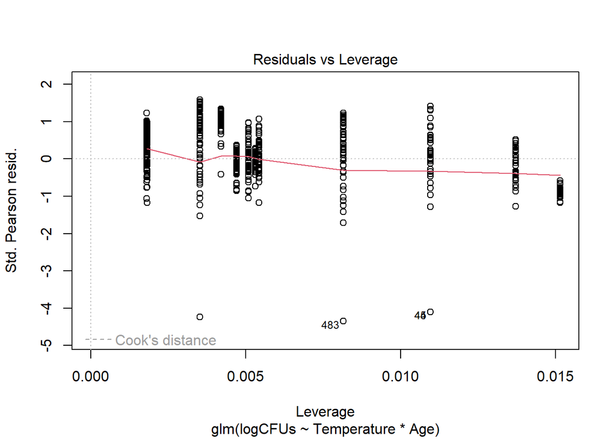

```r
plot(glmQuasiPoisson)
```

```r
glmNegBinomial <- glm.nb(logCFUs ~ Temperature*Age, data=II_Data,link="log")
summary(glmNegBinomial)
```

```
##
## Call:
## glm.nb(formula = logCFUs ~ Temperature * Age, data = II_Data,
##     link = "log", init.theta = 369462.4463)
##
## Deviance Residuals:
##     Min       1Q   Median       3Q      Max
## -4.5231  -0.2298   0.0618   0.4191   1.1047
##
## Coefficients:
##                  Estimate Std. Error z value Pr(>|z|)
## (Intercept)      1.629558   0.329889   4.940 7.82e-07 ***
## Temperature      0.020621   0.011009   1.873 0.061058 .
## Age             -0.099818   0.035812  -2.787 0.005316 **
## Temperature:Age  0.004239   0.001199   3.537 0.000405 ***
## ---
## Signif. codes:  0 '***' 0.001 '**' 0.01 '*' 0.05 '.' 0.1 ' ' 1
##
## (Dispersion parameter for Negative Binomial(369462.4) family taken to be 1)
##
##     Null deviance: 820.35  on 695  degrees of freedom
## Residual deviance: 591.97  on 692  degrees of freedom
## AIC: 3508
##
## Number of Fisher Scoring iterations: 1
##
##
##               Theta:  369462
##           Std. Err.:  1901646
## Warning while fitting theta: iteration limit reached
##
##  2 x log-likelihood:  -3498.034
```

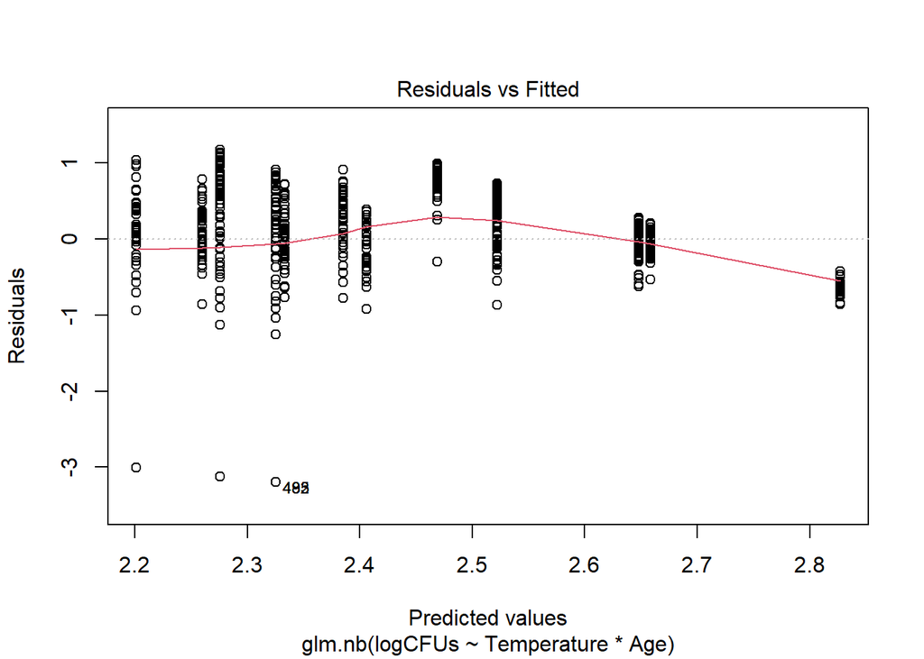

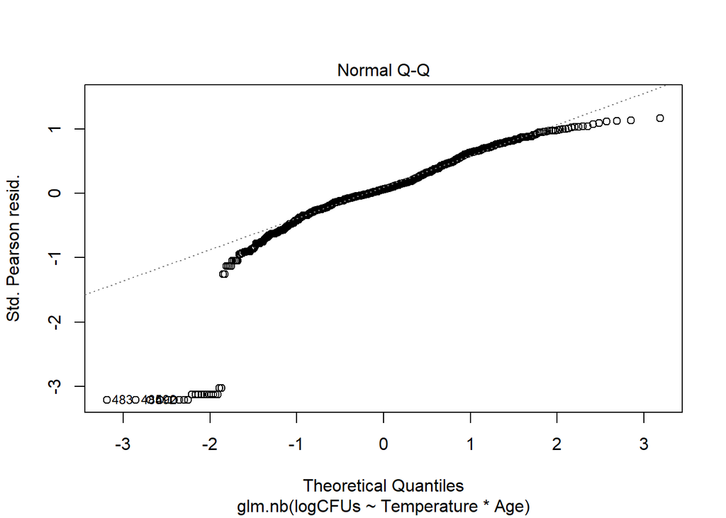

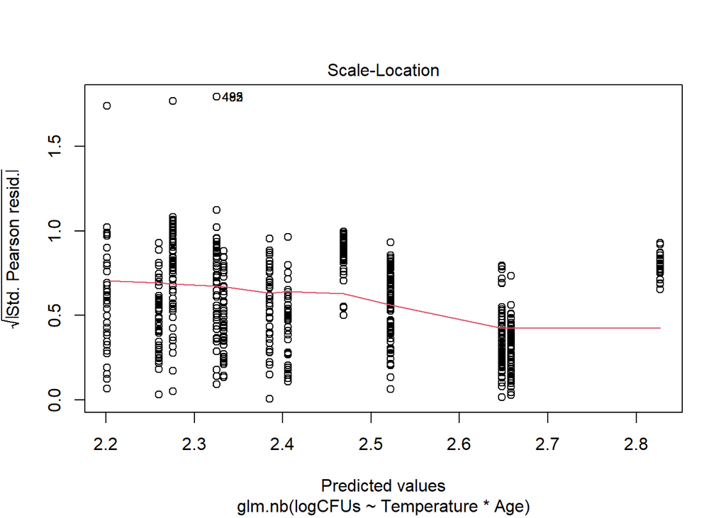

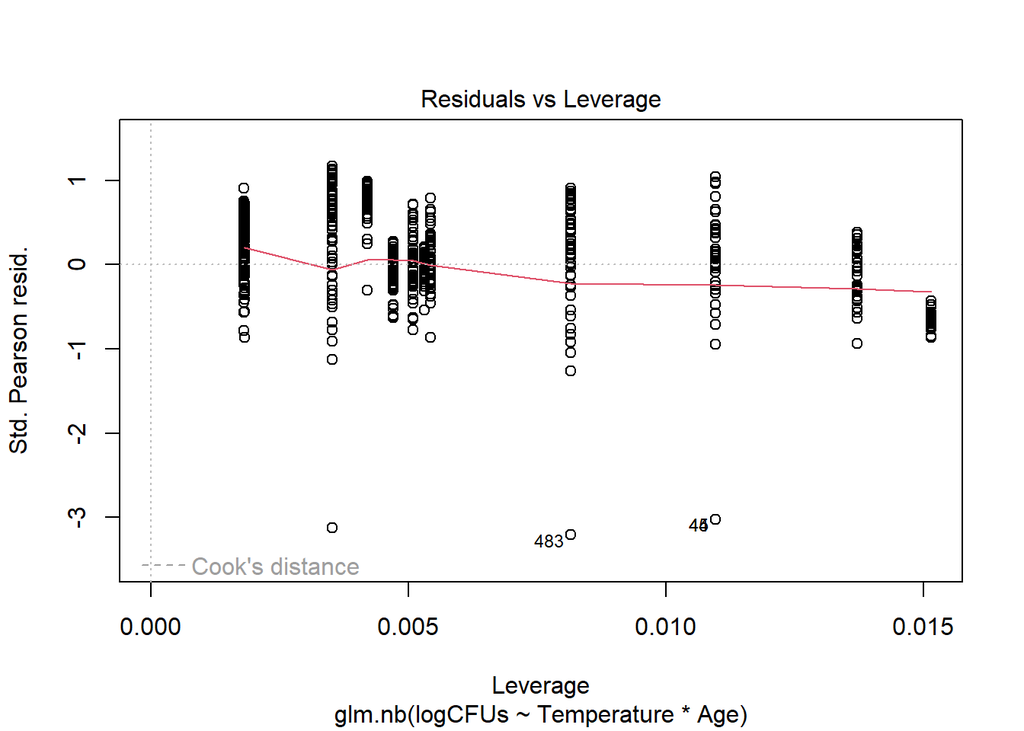

```r
plot(glmNegBinomial)
```

```r
lmlogCFUs <- lm(logCFUs ~ Temperature*Age, data=II_Data)
summary(lmlogCFUs)
```

```
##
## Call:
## lm(formula = logCFUs ~ Temperature * Age, data = II_Data)
##
## Residuals:
##      Min       1Q   Median       3Q      Max
## -10.1073  -0.7128   0.1883   1.3373   3.7108
##
## Coefficients:
##                  Estimate Std. Error t value Pr(>|t|)
## (Intercept)      4.587429   2.426105   1.891   0.0591 .
## Temperature      0.158373   0.081276   1.949   0.0517 .
## Age             -1.525211   0.276945  -5.507 5.14e-08 ***
## Temperature:Age  0.061785   0.009322   6.628 6.85e-11 ***
## ---
## Signif. codes:  0 '***' 0.001 '**' 0.01 '*' 0.05 '.' 0.1 ' ' 1
##
## Residual standard error: 2.336 on 692 degrees of freedom
## Multiple R-squared:  0.4184, Adjusted R-squared:  0.4159
## F-statistic:   166 on 3 and 692 DF,  p-value: < 2.2e-16
```

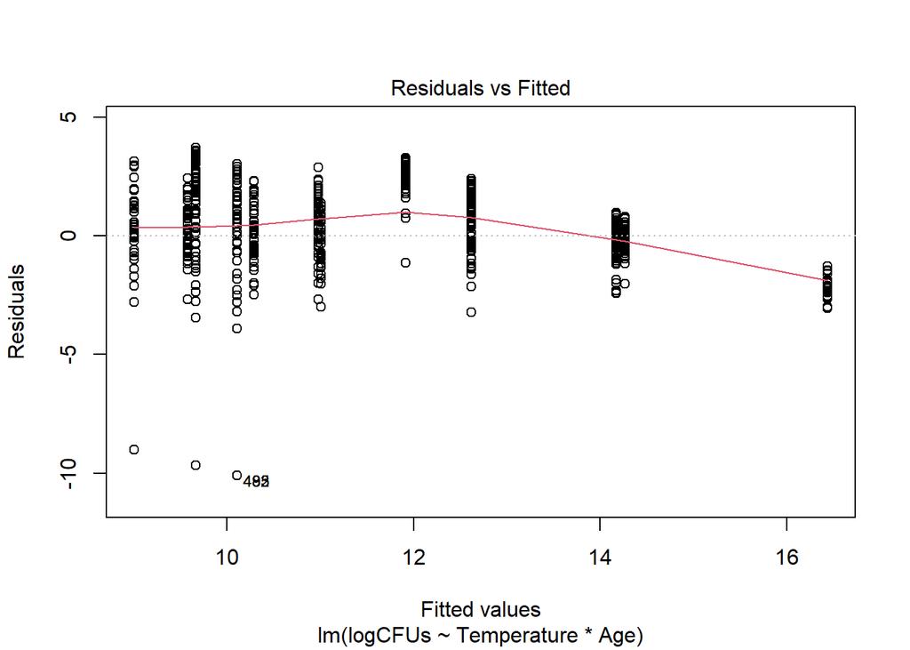

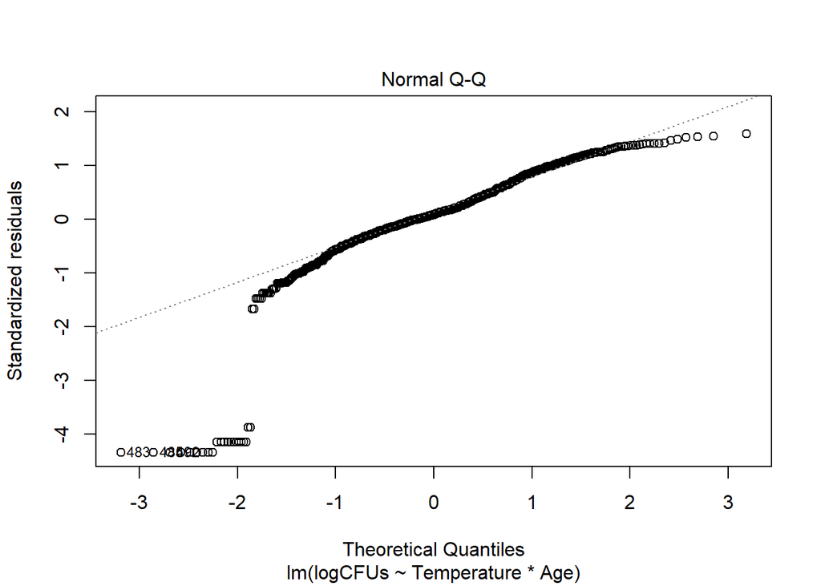

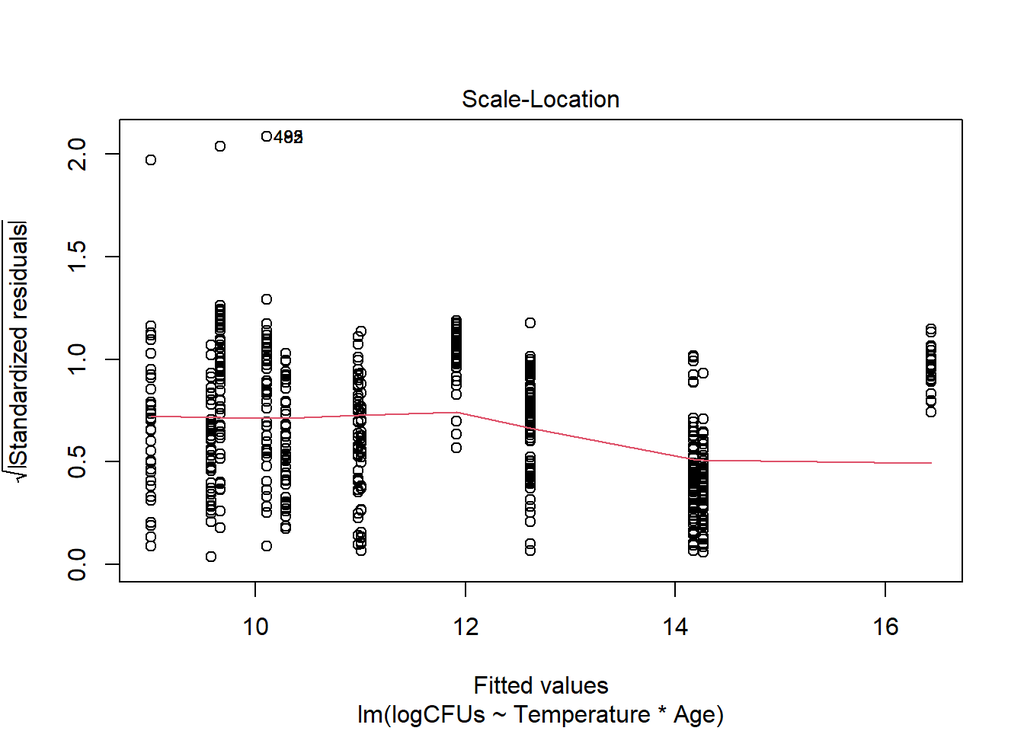

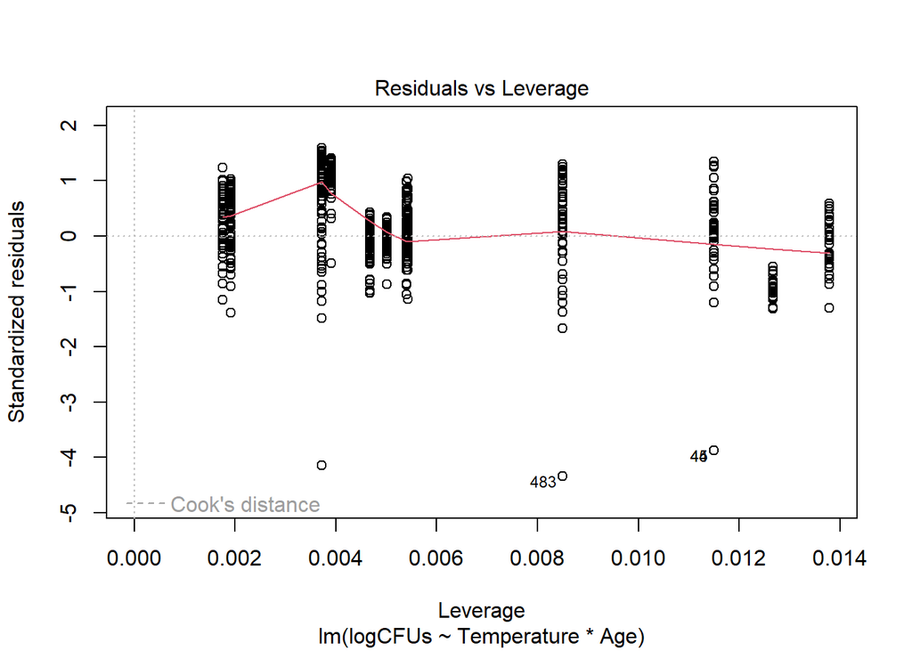

```r
plot(lmlogCFUs)
```

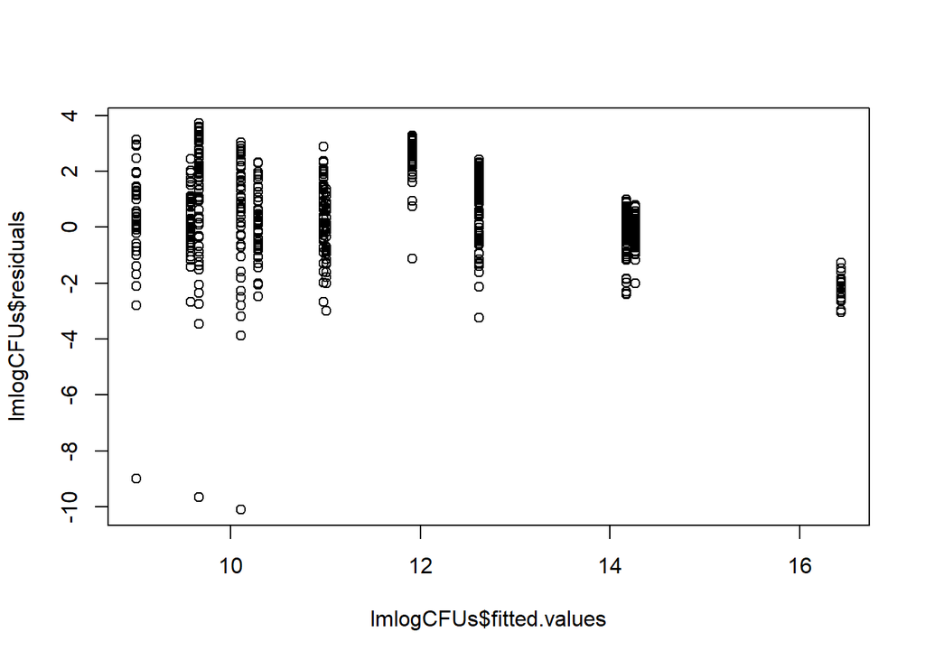

```r
plot(lmlogCFUs$residuals~lmlogCFUs$fitted.values)
```

```r
pr <- residuals(lmlogCFUs,"pearson")
phi <- sum(pr^2)/df.residual(lmlogCFUs)
round(c(phi,sqrt(phi)),4)
```

```
## [1] 5.4554 2.3357
```

```r
#overdispersion present

#looking at plots of models - these are not very good - also not really able to transform data that's already log-transformed
```

It looks like the negative binomial model over-corrects for the overdisperison and that it does not properly account for the excess zero CFU values.

## Fitting a Zero-Inflated Negative Binomial Distribution

Helpful resources: https://www.ncbi.nlm.nih.gov/pmc/articles/PMC5628625/#:~:text=Structural%20zeros%20refer%20to%20zero,zero%20due%20to%20sampling%20variability. https://lanzaroark.org/docs/zero.pdf https://www.jstatsoft.org/article/view/v027i08 https://m-clark.github.io/models-by-example/hurdle.html https://search.r-project.org/CRAN/refmans/pscl/html/hurdle.html https://data.library.virginia.edu/getting-started-with-hurdle-models/ https://www.r-bloggers.com/2013/05/veterinary-epidemiologic-research-count-and-rate-data-zero-counts/ https://stats.oarc.ucla.edu/r/dae/negative-binomial-regression/ https://stats.oarc.ucla.edu/r/dae/zinb/

```r
library(pscl)

#try zero-inflated model instead:
#can include all covariates in each equation or make a simpler model

z1 <- zeroinfl(CFUs ~ Temperature*Age | ## Predictor for the Poisson process
                 Temperature*Age, ## Predictor for the Bernoulli process;
               dist = 'poisson',
               data = II_Data)
#z1 leads to lack of convergence

z2 <- zeroinfl(CFUs ~ Temperature*Age | ## Predictor for the Poisson process
                 1, ## Predictor for the Bernoulli process;
               dist = 'poisson',
               data = II_Data) #simple model
#z2 is the null poisson zero-inflated model
summary(z2)
```

```
##
## Call:
## zeroinfl(formula = CFUs ~ Temperature * Age | 1, data = II_Data, dist = "poisson")
##
## Pearson residuals:
##    Min     1Q Median     3Q    Max
## -5.535 -4.676 -2.360  1.589 40.440
##
## Count model coefficients (poisson with log link):
##                   Estimate Std. Error z value Pr(>|z|)
## (Intercept)     -8.948e+00  4.742e-03   -1887   <2e-16 ***
## Temperature      6.968e-01  1.506e-04    4628   <2e-16 ***
## Age              6.962e-01  4.139e-04    1682   <2e-16 ***
## Temperature:Age -1.862e-02  1.303e-05   -1429   <2e-16 ***
##
## Zero-inflation model coefficients (binomial with logit link):
##             Estimate Std. Error z value Pr(>|z|)
## (Intercept)  -3.4222     0.2167   -15.8   <2e-16 ***
## ---
## Signif. codes:  0 '***' 0.001 '**' 0.01 '*' 0.05 '.' 0.1 ' ' 1
##
## Number of iterations in BFGS optimization: 1
## Log-likelihood: -1.634e+08 on 5 Df
```

```r
#z3 is the null neg bin. zero-inflated model
z3 <- zeroinfl(CFUs ~ Temperature*Age | ## Predictor for the Poisson process
                 1, ## Predictor for the Bernoulli process;
               dist = 'negbin',
               data = II_Data)
summary(z3)
```

```
##
## Call:
## zeroinfl(formula = CFUs ~ Temperature * Age | 1, data = II_Data, dist = "negbin")
##
## Pearson residuals:
##     Min      1Q  Median      3Q     Max
## -0.8665 -0.6830 -0.3692  0.3006  5.8005
##
## Count model coefficients (negbin with log link):
##                  Estimate Std. Error z value Pr(>|z|)
## (Intercept)     -4.364214   1.443458  -3.023 0.002499 **
## Temperature      0.533625   0.048530  10.996  < 2e-16 ***
## Age             -0.556265   0.185236  -3.003 0.002673 **
## Temperature:Age  0.024016   0.006197   3.875 0.000107 ***
## Log(theta)      -0.229650   0.049360  -4.653 3.28e-06 ***
##
## Zero-inflation model coefficients (binomial with logit link):
##             Estimate Std. Error z value Pr(>|z|)
## (Intercept)  -3.4222     0.2169  -15.78   <2e-16 ***
## ---
## Signif. codes:  0 '***' 0.001 '**' 0.01 '*' 0.05 '.' 0.1 ' ' 1
##
## Theta = 0.7948
## Number of iterations in BFGS optimization: 1
## Log-likelihood: -9305 on 6 Df
```

```r
z4 <- zeroinfl(CFUs ~ Temperature*Age | Temperature*Age ## Predictor for the Poisson process
               , ## Predictor for the Bernoulli process;
               dist = 'negbin',
               data = II_Data)
summary(z4)
```

```
##
## Call:
## zeroinfl(formula = CFUs ~ Temperature * Age | Temperature * Age, data = II_Data,
##     dist = "negbin")
##
## Pearson residuals:
##     Min      1Q  Median      3Q     Max
## -0.8778 -0.6868 -0.3714  0.2812  5.8442
##
## Count model coefficients (negbin with log link):
##                  Estimate Std. Error z value Pr(>|z|)
## (Intercept)     -4.364214   1.443162  -3.024 0.002494 **
## Temperature      0.533625   0.048520  10.998  < 2e-16 ***
## Age             -0.556265   0.185193  -3.004 0.002667 **
## Temperature:Age  0.024016   0.006196   3.876 0.000106 ***
## Log(theta)      -0.229650   0.049235  -4.664  3.1e-06 ***
##
## Zero-inflation model coefficients (binomial with logit link):
##                   Estimate Std. Error z value Pr(>|z|)
## (Intercept)       -6.26495 6846.89272  -0.001    0.999
## Temperature        0.28871  229.93548   0.001    0.999
## Age               -2.79575 6846.89081   0.000    1.000
## Temperature:Age   -0.05693  229.93542   0.000    1.000
## ---
## Signif. codes:  0 '***' 0.001 '**' 0.01 '*' 0.05 '.' 0.1 ' ' 1
##
## Theta = 0.7948
## Number of iterations in BFGS optimization: 1
## Log-likelihood: -9274 on 9 Df
```

```r
#z4 leads to lack of convergence; Std errors of ZI model are too large

z5 <- zeroinfl(CFUs ~ Temperature*Age | Temperature+Age ## Predictor for the Poisson process
               , ## Predictor for the Bernoulli process;
               dist = 'negbin',
               data = II_Data)
summary(z5)
```

```
##
## Call:
## zeroinfl(formula = CFUs ~ Temperature * Age | Temperature + Age, data = II_Data,
##     dist = "negbin")
##
## Pearson residuals:
##     Min      1Q  Median      3Q     Max
## -0.8778 -0.6868 -0.3714  0.2812  5.8442
##
## Count model coefficients (negbin with log link):
##                  Estimate Std. Error z value Pr(>|z|)
## (Intercept)     -4.364214   1.443162  -3.024 0.002494 **
## Temperature      0.533625   0.048520  10.998  < 2e-16 ***
## Age             -0.556265   0.185193  -3.004 0.002667 **
## Temperature:Age  0.024016   0.006196   3.876 0.000106 ***
## Log(theta)      -0.229650   0.049235  -4.664  3.1e-06 ***
##
## Zero-inflation model coefficients (binomial with logit link):
##             Estimate Std. Error z value Pr(>|z|)
## (Intercept)  -4.5573   468.6745  -0.010   0.9922
## Temperature   0.2318     0.1368   1.695   0.0901 .
## Age          -4.5034   468.6559  -0.010   0.9923
## ---
## Signif. codes:  0 '***' 0.001 '**' 0.01 '*' 0.05 '.' 0.1 ' ' 1
##
## Theta = 0.7948
## Number of iterations in BFGS optimization: 1
## Log-likelihood: -9274 on 8 Df
```

```r
#z5 leads to lack of convergence; Std errors of ZI model  coeff for Intercept and Age are too large

z6 <- zeroinfl(CFUs ~ Temperature*Age | Temperature ## Predictor for the Poisson process
               , ## Predictor for the Bernoulli process;
               dist = 'negbin',
               data = II_Data)
summary(z6)
```

```
##
## Call:
## zeroinfl(formula = CFUs ~ Temperature * Age | Temperature, data = II_Data,
##     dist = "negbin")
##
## Pearson residuals:
##     Min      1Q  Median      3Q     Max
## -0.8796 -0.6843 -0.3664  0.2950  5.7739
##
## Count model coefficients (negbin with log link):
##                  Estimate Std. Error z value Pr(>|z|)
## (Intercept)     -4.364214   1.443875  -3.023 0.002506 **
## Temperature      0.533625   0.048544  10.993  < 2e-16 ***
## Age             -0.556265   0.185287  -3.002 0.002680 **
## Temperature:Age  0.024016   0.006199   3.874 0.000107 ***
## Log(theta)      -0.229650   0.049410  -4.648 3.35e-06 ***
##
## Zero-inflation model coefficients (binomial with logit link):
##             Estimate Std. Error z value Pr(>|z|)
## (Intercept) -10.7180     3.9482  -2.715  0.00663 **
## Temperature   0.2419     0.1291   1.873  0.06100 .
## ---
## Signif. codes:  0 '***' 0.001 '**' 0.01 '*' 0.05 '.' 0.1 ' ' 1
##
## Theta = 0.7948
## Number of iterations in BFGS optimization: 1
## Log-likelihood: -9303 on 7 Df
```

```r
z7 <- zeroinfl(CFUs ~ Temperature*Age | Age ## Predictor for the Poisson process
               , ## Predictor for the Bernoulli process;
               dist = 'negbin',
               data = II_Data)
summary(z7)
```

```
##
## Call:
## zeroinfl(formula = CFUs ~ Temperature * Age | Age, data = II_Data, dist = "negbin")
##
## Pearson residuals:
##     Min      1Q  Median      3Q     Max
## -0.8778 -0.6803 -0.3676  0.2812  5.9516
##
## Count model coefficients (negbin with log link):
##                  Estimate Std. Error z value Pr(>|z|)
## (Intercept)     -4.364214   1.443057  -3.024 0.002492 **
## Temperature      0.533625   0.048517  10.999  < 2e-16 ***
## Age             -0.556265   0.185180  -3.004 0.002665 **
## Temperature:Age  0.024016   0.006196   3.876 0.000106 ***
## Log(theta)      -0.229650   0.049223  -4.666 3.08e-06 ***
##
## Zero-inflation model coefficients (binomial with logit link):
##             Estimate Std. Error z value Pr(>|z|)
## (Intercept)    2.453    473.483   0.005    0.996
## Age           -4.515    473.483  -0.010    0.992
## ---
## Signif. codes:  0 '***' 0.001 '**' 0.01 '*' 0.05 '.' 0.1 ' ' 1
##
## Theta = 0.7948
## Number of iterations in BFGS optimization: 1
## Log-likelihood: -9276 on 7 Df
```

```r
#z7 leads to lack of convergence; Std errors of ZI model Int and Age are too large
```